# Data Wrangling Project - We Love Dogs

```python
import pandas as pd
import numpy as np
import matplotlib.pyplot as plt
```

## Gather

### Reading the files

All the information will be loaded in this section. the files loaded will be the following:

1. Twitter Archive
2. Tweet JSON (changed .txt file type with .json file type before uploading)
3. Image predictions

```python
t_archive = pd.read_csv('twitter-archive-enhanced.csv')
```

```python
t_json = pd.read_json('tweet_json.json', lines=True)
```

```python
image_predictions = pd.read_csv('image-predictions-3.tsv', sep='\t')
```

## Assess

### Visual Assesment

I chose to do the visual assessment right here by displaying the three tables.

```python
t_archive
```

|  | tweet_id | in_reply_to_status_id | in_reply_to_user_id | timestamp | source | text | retweeted_status_id | retweeted_status_user_id | retweeted_status_timestamp | expanded_urls | rating_numerator | rating_denominator | name | doggo | floofer | pupper | puppo |
| --- | --- | --- | --- | --- | --- | --- | --- | --- | --- | --- | --- | --- | --- | --- | --- | --- | --- |
| 0 | 892420643555336193 | NaN | NaN | 2017-08-01 16:23:56 +0000 | <a href="http://twitter.com/download/iphone" r... | This is Phineas. He's a mystical boy. Only eve... | NaN | NaN | NaN | https://twitter.com/dog_rates/status/892420643... | 13 | 10 | Phineas | None | None | None | None |
| 1 | 892177421306343426 | NaN | NaN | 2017-08-01 00:17:27 +0000 | <a href="http://twitter.com/download/iphone" r... | This is Tilly. She's just checking pup on you.... | NaN | NaN | NaN | https://twitter.com/dog_rates/status/892177421... | 13 | 10 | Tilly | None | None | None | None |
| 2 | 891815181378084864 | NaN | NaN | 2017-07-31 00:18:03 +0000 | <a href="http://twitter.com/download/iphone" r... | This is Archie. He is a rare Norwegian Pouncin... | NaN | NaN | NaN | https://twitter.com/dog_rates/status/891815181... | 12 | 10 | Archie | None | None | None | None |
| 3 | 891689557279858688 | NaN | NaN | 2017-07-30 15:58:51 +0000 | <a href="http://twitter.com/download/iphone" r... | This is Darla. She commenced a snooze mid meal... | NaN | NaN | NaN | https://twitter.com/dog_rates/status/891689557... | 13 | 10 | Darla | None | None | None | None |
| 4 | 891327558926688256 | NaN | NaN | 2017-07-29 16:00:24 +0000 | <a href="http://twitter.com/download/iphone" r... | This is Franklin. He would like you to stop ca... | NaN | NaN | NaN | https://twitter.com/dog_rates/status/891327558... | 12 | 10 | Franklin | None | None | None | None |
| 5 | 891087950875897856 | NaN | NaN | 2017-07-29 00:08:17 +0000 | <a href="http://twitter.com/download/iphone" r... | Here we have a majestic great white breaching ... | NaN | NaN | NaN | https://twitter.com/dog_rates/status/891087950... | 13 | 10 | None | None | None | None | None |
| 6 | 890971913173991426 | NaN | NaN | 2017-07-28 16:27:12 +0000 | <a href="http://twitter.com/download/iphone" r... | Meet Jax. He enjoys ice cream so much he gets ... | NaN | NaN | NaN | https://gofundme.com/ydvmve-surgery-for-jax,ht... | 13 | 10 | Jax | None | None | None | None |
| 7 | 890729181411237888 | NaN | NaN | 2017-07-28 00:22:40 +0000 | <a href="http://twitter.com/download/iphone" r... | When you watch your owner call another dog a g... | NaN | NaN | NaN | https://twitter.com/dog_rates/status/890729181... | 13 | 10 | None | None | None | None | None |
| 8 | 890609185150312448 | NaN | NaN | 2017-07-27 16:25:51 +0000 | <a href="http://twitter.com/download/iphone" r... | This is Zoey. She doesn't want to be one of th... | NaN | NaN | NaN | https://twitter.com/dog_rates/status/890609185... | 13 | 10 | Zoey | None | None | None | None |
| 9 | 890240255349198849 | NaN | NaN | 2017-07-26 15:59:51 +0000 | <a href="http://twitter.com/download/iphone" r... | This is Cassie. She is a college pup. Studying... | NaN | NaN | NaN | https://twitter.com/dog_rates/status/890240255... | 14 | 10 | Cassie | doggo | None | None | None |
| 10 | 890006608113172480 | NaN | NaN | 2017-07-26 00:31:25 +0000 | <a href="http://twitter.com/download/iphone" r... | This is Koda. He is a South Australian decksha... | NaN | NaN | NaN | https://twitter.com/dog_rates/status/890006608... | 13 | 10 | Koda | None | None | None | None |
| 11 | 889880896479866881 | NaN | NaN | 2017-07-25 16:11:53 +0000 | <a href="http://twitter.com/download/iphone" r... | This is Bruno. He is a service shark. Only get... | NaN | NaN | NaN | https://twitter.com/dog_rates/status/889880896... | 13 | 10 | Bruno | None | None | None | None |
| 12 | 889665388333682689 | NaN | NaN | 2017-07-25 01:55:32 +0000 | <a href="http://twitter.com/download/iphone" r... | Here's a puppo that seems to be on the fence a... | NaN | NaN | NaN | https://twitter.com/dog_rates/status/889665388... | 13 | 10 | None | None | None | None | puppo |
| 13 | 889638837579907072 | NaN | NaN | 2017-07-25 00:10:02 +0000 | <a href="http://twitter.com/download/iphone" r... | This is Ted. He does his best. Sometimes that'... | NaN | NaN | NaN | https://twitter.com/dog_rates/status/889638837... | 12 | 10 | Ted | None | None | None | None |
| 14 | 889531135344209921 | NaN | NaN | 2017-07-24 17:02:04 +0000 | <a href="http://twitter.com/download/iphone" r... | This is Stuart. He's sporting his favorite fan... | NaN | NaN | NaN | https://twitter.com/dog_rates/status/889531135... | 13 | 10 | Stuart | None | None | None | puppo |
| 15 | 889278841981685760 | NaN | NaN | 2017-07-24 00:19:32 +0000 | <a href="http://twitter.com/download/iphone" r... | This is Oliver. You're witnessing one of his m... | NaN | NaN | NaN | https://twitter.com/dog_rates/status/889278841... | 13 | 10 | Oliver | None | None | None | None |
| 16 | 888917238123831296 | NaN | NaN | 2017-07-23 00:22:39 +0000 | <a href="http://twitter.com/download/iphone" r... | This is Jim. He found a fren. Taught him how t... | NaN | NaN | NaN | https://twitter.com/dog_rates/status/888917238... | 12 | 10 | Jim | None | None | None | None |
| 17 | 888804989199671297 | NaN | NaN | 2017-07-22 16:56:37 +0000 | <a href="http://twitter.com/download/iphone" r... | This is Zeke. He has a new stick. Very proud o... | NaN | NaN | NaN | https://twitter.com/dog_rates/status/888804989... | 13 | 10 | Zeke | None | None | None | None |
| 18 | 888554962724278272 | NaN | NaN | 2017-07-22 00:23:06 +0000 | <a href="http://twitter.com/download/iphone" r... | This is Ralphus. He's powering up. Attempting ... | NaN | NaN | NaN | https://twitter.com/dog_rates/status/888554962... | 13 | 10 | Ralphus | None | None | None | None |
| 19 | 888202515573088257 | NaN | NaN | 2017-07-21 01:02:36 +0000 | <a href="http://twitter.com/download/iphone" r... | RT @dog_rates: This is Canela. She attempted s... | 8.874740e+17 | 4.196984e+09 | 2017-07-19 00:47:34 +0000 | https://twitter.com/dog_rates/status/887473957... | 13 | 10 | Canela | None | None | None | None |
| 20 | 888078434458587136 | NaN | NaN | 2017-07-20 16:49:33 +0000 | <a href="http://twitter.com/download/iphone" r... | This is Gerald. He was just told he didn't get... | NaN | NaN | NaN | https://twitter.com/dog_rates/status/888078434... | 12 | 10 | Gerald | None | None | None | None |
| 21 | 887705289381826560 | NaN | NaN | 2017-07-19 16:06:48 +0000 | <a href="http://twitter.com/download/iphone" r... | This is Jeffrey. He has a monopoly on the pool... | NaN | NaN | NaN | https://twitter.com/dog_rates/status/887705289... | 13 | 10 | Jeffrey | None | None | None | None |
| 22 | 887517139158093824 | NaN | NaN | 2017-07-19 03:39:09 +0000 | <a href="http://twitter.com/download/iphone" r... | I've yet to rate a Venezuelan Hover Wiener. Th... | NaN | NaN | NaN | https://twitter.com/dog_rates/status/887517139... | 14 | 10 | such | None | None | None | None |
| 23 | 887473957103951883 | NaN | NaN | 2017-07-19 00:47:34 +0000 | <a href="http://twitter.com/download/iphone" r... | This is Canela. She attempted some fancy porch... | NaN | NaN | NaN | https://twitter.com/dog_rates/status/887473957... | 13 | 10 | Canela | None | None | None | None |
| 24 | 887343217045368832 | NaN | NaN | 2017-07-18 16:08:03 +0000 | <a href="http://twitter.com/download/iphone" r... | You may not have known you needed to see this ... | NaN | NaN | NaN | https://twitter.com/dog_rates/status/887343217... | 13 | 10 | None | None | None | None | None |
| 25 | 887101392804085760 | NaN | NaN | 2017-07-18 00:07:08 +0000 | <a href="http://twitter.com/download/iphone" r... | This... is a Jubilant Antarctic House Bear. We... | NaN | NaN | NaN | https://twitter.com/dog_rates/status/887101392... | 12 | 10 | None | None | None | None | None |
| 26 | 886983233522544640 | NaN | NaN | 2017-07-17 16:17:36 +0000 | <a href="http://twitter.com/download/iphone" r... | This is Maya. She's very shy. Rarely leaves he... | NaN | NaN | NaN | https://twitter.com/dog_rates/status/886983233... | 13 | 10 | Maya | None | None | None | None |
| 27 | 886736880519319552 | NaN | NaN | 2017-07-16 23:58:41 +0000 | <a href="http://twitter.com/download/iphone" r... | This is Mingus. He's a wonderful father to his... | NaN | NaN | NaN | https://www.gofundme.com/mingusneedsus,https:/... | 13 | 10 | Mingus | None | None | None | None |
| 28 | 886680336477933568 | NaN | NaN | 2017-07-16 20:14:00 +0000 | <a href="http://twitter.com/download/iphone" r... | This is Derek. He's late for a dog meeting. 13... | NaN | NaN | NaN | https://twitter.com/dog_rates/status/886680336... | 13 | 10 | Derek | None | None | None | None |
| 29 | 886366144734445568 | NaN | NaN | 2017-07-15 23:25:31 +0000 | <a href="http://twitter.com/download/iphone" r... | This is Roscoe. Another pupper fallen victim t... | NaN | NaN | NaN | https://twitter.com/dog_rates/status/886366144... | 12 | 10 | Roscoe | None | None | pupper | None |
| ... | ... | ... | ... | ... | ... | ... | ... | ... | ... | ... | ... | ... | ... | ... | ... | ... | ... |
| 2326 | 666411507551481857 | NaN | NaN | 2015-11-17 00:24:19 +0000 | <a href="http://twitter.com/download/iphone" r... | This is quite the dog. Gets really excited whe... | NaN | NaN | NaN | https://twitter.com/dog_rates/status/666411507... | 2 | 10 | quite | None | None | None | None |
| 2327 | 666407126856765440 | NaN | NaN | 2015-11-17 00:06:54 +0000 | <a href="http://twitter.com/download/iphone" r... | This is a southern Vesuvius bumblegruff. Can d... | NaN | NaN | NaN | https://twitter.com/dog_rates/status/666407126... | 7 | 10 | a | None | None | None | None |
| 2328 | 666396247373291520 | NaN | NaN | 2015-11-16 23:23:41 +0000 | <a href="http://twitter.com/download/iphone" r... | Oh goodness. A super rare northeast Qdoba kang... | NaN | NaN | NaN | https://twitter.com/dog_rates/status/666396247... | 9 | 10 | None | None | None | None | None |
| 2329 | 666373753744588802 | NaN | NaN | 2015-11-16 21:54:18 +0000 | <a href="http://twitter.com/download/iphone" r... | Those are sunglasses and a jean jacket. 11/10 ... | NaN | NaN | NaN | https://twitter.com/dog_rates/status/666373753... | 11 | 10 | None | None | None | None | None |
| 2330 | 666362758909284353 | NaN | NaN | 2015-11-16 21:10:36 +0000 | <a href="http://twitter.com/download/iphone" r... | Unique dog here. Very small. Lives in containe... | NaN | NaN | NaN | https://twitter.com/dog_rates/status/666362758... | 6 | 10 | None | None | None | None | None |
| 2331 | 666353288456101888 | NaN | NaN | 2015-11-16 20:32:58 +0000 | <a href="http://twitter.com/download/iphone" r... | Here we have a mixed Asiago from the Galápagos... | NaN | NaN | NaN | https://twitter.com/dog_rates/status/666353288... | 8 | 10 | None | None | None | None | None |
| 2332 | 666345417576210432 | NaN | NaN | 2015-11-16 20:01:42 +0000 | <a href="http://twitter.com/download/iphone" r... | Look at this jokester thinking seat belt laws ... | NaN | NaN | NaN | https://twitter.com/dog_rates/status/666345417... | 10 | 10 | None | None | None | None | None |
| 2333 | 666337882303524864 | NaN | NaN | 2015-11-16 19:31:45 +0000 | <a href="http://twitter.com/download/iphone" r... | This is an extremely rare horned Parthenon. No... | NaN | NaN | NaN | https://twitter.com/dog_rates/status/666337882... | 9 | 10 | an | None | None | None | None |
| 2334 | 666293911632134144 | NaN | NaN | 2015-11-16 16:37:02 +0000 | <a href="http://twitter.com/download/iphone" r... | This is a funny dog. Weird toes. Won't come do... | NaN | NaN | NaN | https://twitter.com/dog_rates/status/666293911... | 3 | 10 | a | None | None | None | None |
| 2335 | 666287406224695296 | NaN | NaN | 2015-11-16 16:11:11 +0000 | <a href="http://twitter.com/download/iphone" r... | This is an Albanian 3 1/2 legged Episcopalian... | NaN | NaN | NaN | https://twitter.com/dog_rates/status/666287406... | 1 | 2 | an | None | None | None | None |
| 2336 | 666273097616637952 | NaN | NaN | 2015-11-16 15:14:19 +0000 | <a href="http://twitter.com/download/iphone" r... | Can take selfies 11/10 https://t.co/ws2AMaNwPW | NaN | NaN | NaN | https://twitter.com/dog_rates/status/666273097... | 11 | 10 | None | None | None | None | None |
| 2337 | 666268910803644416 | NaN | NaN | 2015-11-16 14:57:41 +0000 | <a href="http://twitter.com/download/iphone" r... | Very concerned about fellow dog trapped in com... | NaN | NaN | NaN | https://twitter.com/dog_rates/status/666268910... | 10 | 10 | None | None | None | None | None |
| 2338 | 666104133288665088 | NaN | NaN | 2015-11-16 04:02:55 +0000 | <a href="http://twitter.com/download/iphone" r... | Not familiar with this breed. No tail (weird).... | NaN | NaN | NaN | https://twitter.com/dog_rates/status/666104133... | 1 | 10 | None | None | None | None | None |
| 2339 | 666102155909144576 | NaN | NaN | 2015-11-16 03:55:04 +0000 | <a href="http://twitter.com/download/iphone" r... | Oh my. Here you are seeing an Adobe Setter giv... | NaN | NaN | NaN | https://twitter.com/dog_rates/status/666102155... | 11 | 10 | None | None | None | None | None |
| 2340 | 666099513787052032 | NaN | NaN | 2015-11-16 03:44:34 +0000 | <a href="http://twitter.com/download/iphone" r... | Can stand on stump for what seems like a while... | NaN | NaN | NaN | https://twitter.com/dog_rates/status/666099513... | 8 | 10 | None | None | None | None | None |
| 2341 | 666094000022159362 | NaN | NaN | 2015-11-16 03:22:39 +0000 | <a href="http://twitter.com/download/iphone" r... | This appears to be a Mongolian Presbyterian mi... | NaN | NaN | NaN | https://twitter.com/dog_rates/status/666094000... | 9 | 10 | None | None | None | None | None |
| 2342 | 666082916733198337 | NaN | NaN | 2015-11-16 02:38:37 +0000 | <a href="http://twitter.com/download/iphone" r... | Here we have a well-established sunblockerspan... | NaN | NaN | NaN | https://twitter.com/dog_rates/status/666082916... | 6 | 10 | None | None | None | None | None |
| 2343 | 666073100786774016 | NaN | NaN | 2015-11-16 01:59:36 +0000 | <a href="http://twitter.com/download/iphone" r... | Let's hope this flight isn't Malaysian (lol). ... | NaN | NaN | NaN | https://twitter.com/dog_rates/status/666073100... | 10 | 10 | None | None | None | None | None |
| 2344 | 666071193221509120 | NaN | NaN | 2015-11-16 01:52:02 +0000 | <a href="http://twitter.com/download/iphone" r... | Here we have a northern speckled Rhododendron.... | NaN | NaN | NaN | https://twitter.com/dog_rates/status/666071193... | 9 | 10 | None | None | None | None | None |
| 2345 | 666063827256086533 | NaN | NaN | 2015-11-16 01:22:45 +0000 | <a href="http://twitter.com/download/iphone" r... | This is the happiest dog you will ever see. Ve... | NaN | NaN | NaN | https://twitter.com/dog_rates/status/666063827... | 10 | 10 | the | None | None | None | None |
| 2346 | 666058600524156928 | NaN | NaN | 2015-11-16 01:01:59 +0000 | <a href="http://twitter.com/download/iphone" r... | Here is the Rand Paul of retrievers folks! He'... | NaN | NaN | NaN | https://twitter.com/dog_rates/status/666058600... | 8 | 10 | the | None | None | None | None |
| 2347 | 666057090499244032 | NaN | NaN | 2015-11-16 00:55:59 +0000 | <a href="http://twitter.com/download/iphone" r... | My oh my. This is a rare blond Canadian terrie... | NaN | NaN | NaN | https://twitter.com/dog_rates/status/666057090... | 9 | 10 | a | None | None | None | None |
| 2348 | 666055525042405380 | NaN | NaN | 2015-11-16 00:49:46 +0000 | <a href="http://twitter.com/download/iphone" r... | Here is a Siberian heavily armored polar bear ... | NaN | NaN | NaN | https://twitter.com/dog_rates/status/666055525... | 10 | 10 | a | None | None | None | None |
| 2349 | 666051853826850816 | NaN | NaN | 2015-11-16 00:35:11 +0000 | <a href="http://twitter.com/download/iphone" r... | This is an odd dog. Hard on the outside but lo... | NaN | NaN | NaN | https://twitter.com/dog_rates/status/666051853... | 2 | 10 | an | None | None | None | None |
| 2350 | 666050758794694657 | NaN | NaN | 2015-11-16 00:30:50 +0000 | <a href="http://twitter.com/download/iphone" r... | This is a truly beautiful English Wilson Staff... | NaN | NaN | NaN | https://twitter.com/dog_rates/status/666050758... | 10 | 10 | a | None | None | None | None |
| 2351 | 666049248165822465 | NaN | NaN | 2015-11-16 00:24:50 +0000 | <a href="http://twitter.com/download/iphone" r... | Here we have a 1949 1st generation vulpix. Enj... | NaN | NaN | NaN | https://twitter.com/dog_rates/status/666049248... | 5 | 10 | None | None | None | None | None |
| 2352 | 666044226329800704 | NaN | NaN | 2015-11-16 00:04:52 +0000 | <a href="http://twitter.com/download/iphone" r... | This is a purebred Piers Morgan. Loves to Netf... | NaN | NaN | NaN | https://twitter.com/dog_rates/status/666044226... | 6 | 10 | a | None | None | None | None |
| 2353 | 666033412701032449 | NaN | NaN | 2015-11-15 23:21:54 +0000 | <a href="http://twitter.com/download/iphone" r... | Here is a very happy pup. Big fan of well-main... | NaN | NaN | NaN | https://twitter.com/dog_rates/status/666033412... | 9 | 10 | a | None | None | None | None |
| 2354 | 666029285002620928 | NaN | NaN | 2015-11-15 23:05:30 +0000 | <a href="http://twitter.com/download/iphone" r... | This is a western brown Mitsubishi terrier. Up... | NaN | NaN | NaN | https://twitter.com/dog_rates/status/666029285... | 7 | 10 | a | None | None | None | None |
| 2355 | 666020888022790149 | NaN | NaN | 2015-11-15 22:32:08 +0000 | <a href="http://twitter.com/download/iphone" r... | Here we have a Japanese Irish Setter. Lost eye... | NaN | NaN | NaN | https://twitter.com/dog_rates/status/666020888... | 8 | 10 | None | None | None | None | None |

2356 rows × 17 columns

```python
t_json
```

|  | contributors | coordinates | created_at | display_text_range | entities | extended_entities | favorite_count | favorited | full_text | geo | ... | possibly_sensitive_appealable | quoted_status | quoted_status_id | quoted_status_id_str | retweet_count | retweeted | retweeted_status | source | truncated | user |
| --- | --- | --- | --- | --- | --- | --- | --- | --- | --- | --- | --- | --- | --- | --- | --- | --- | --- | --- | --- | --- | --- |
| 0 | NaN | NaN | 2017-08-01 16:23:56 | [0, 85] | {'hashtags': [], 'symbols': [], 'user_mentions... | {'media': [{'id': 892420639486877696, 'id_str'... | 39467 | False | This is Phineas. He's a mystical boy. Only eve... | NaN | ... | 0.0 | NaN | NaN | NaN | 8853 | False | NaN | <a href="http://twitter.com/download/iphone" r... | False | {'id': 4196983835, 'id_str': '4196983835', 'na... |
| 1 | NaN | NaN | 2017-08-01 00:17:27 | [0, 138] | {'hashtags': [], 'symbols': [], 'user_mentions... | {'media': [{'id': 892177413194625024, 'id_str'... | 33819 | False | This is Tilly. She's just checking pup on you.... | NaN | ... | 0.0 | NaN | NaN | NaN | 6514 | False | NaN | <a href="http://twitter.com/download/iphone" r... | False | {'id': 4196983835, 'id_str': '4196983835', 'na... |
| 2 | NaN | NaN | 2017-07-31 00:18:03 | [0, 121] | {'hashtags': [], 'symbols': [], 'user_mentions... | {'media': [{'id': 891815175371796480, 'id_str'... | 25461 | False | This is Archie. He is a rare Norwegian Pouncin... | NaN | ... | 0.0 | NaN | NaN | NaN | 4328 | False | NaN | <a href="http://twitter.com/download/iphone" r... | False | {'id': 4196983835, 'id_str': '4196983835', 'na... |
| 3 | NaN | NaN | 2017-07-30 15:58:51 | [0, 79] | {'hashtags': [], 'symbols': [], 'user_mentions... | {'media': [{'id': 891689552724799489, 'id_str'... | 42908 | False | This is Darla. She commenced a snooze mid meal... | NaN | ... | 0.0 | NaN | NaN | NaN | 8964 | False | NaN | <a href="http://twitter.com/download/iphone" r... | False | {'id': 4196983835, 'id_str': '4196983835', 'na... |
| 4 | NaN | NaN | 2017-07-29 16:00:24 | [0, 138] | {'hashtags': [{'text': 'BarkWeek', 'indices': ... | {'media': [{'id': 891327551943041024, 'id_str'... | 41048 | False | This is Franklin. He would like you to stop ca... | NaN | ... | 0.0 | NaN | NaN | NaN | 9774 | False | NaN | <a href="http://twitter.com/download/iphone" r... | False | {'id': 4196983835, 'id_str': '4196983835', 'na... |
| 5 | NaN | NaN | 2017-07-29 00:08:17 | [0, 138] | {'hashtags': [{'text': 'BarkWeek', 'indices': ... | {'media': [{'id': 891087942176911360, 'id_str'... | 20562 | False | Here we have a majestic great white breaching ... | NaN | ... | 0.0 | NaN | NaN | NaN | 3261 | False | NaN | <a href="http://twitter.com/download/iphone" r... | False | {'id': 4196983835, 'id_str': '4196983835', 'na... |
| 6 | NaN | NaN | 2017-07-28 16:27:12 | [0, 140] | {'hashtags': [], 'symbols': [], 'user_mentions... | {'media': [{'id': 890971906207338496, 'id_str'... | 12041 | False | Meet Jax. He enjoys ice cream so much he gets ... | NaN | ... | 0.0 | NaN | NaN | NaN | 2158 | False | NaN | <a href="http://twitter.com/download/iphone" r... | False | {'id': 4196983835, 'id_str': '4196983835', 'na... |
| 7 | NaN | NaN | 2017-07-28 00:22:40 | [0, 118] | {'hashtags': [], 'symbols': [], 'user_mentions... | {'media': [{'id': 890729118844600320, 'id_str'... | 56848 | False | When you watch your owner call another dog a g... | NaN | ... | 0.0 | NaN | NaN | NaN | 16716 | False | NaN | <a href="http://twitter.com/download/iphone" r... | False | {'id': 4196983835, 'id_str': '4196983835', 'na... |
| 8 | NaN | NaN | 2017-07-27 16:25:51 | [0, 122] | {'hashtags': [{'text': 'BarkWeek', 'indices': ... | {'media': [{'id': 890609177319665665, 'id_str'... | 28226 | False | This is Zoey. She doesn't want to be one of th... | NaN | ... | 0.0 | NaN | NaN | NaN | 4429 | False | NaN | <a href="http://twitter.com/download/iphone" r... | False | {'id': 4196983835, 'id_str': '4196983835', 'na... |
| 9 | NaN | NaN | 2017-07-26 15:59:51 | [0, 133] | {'hashtags': [], 'symbols': [], 'user_mentions... | {'media': [{'id': 890240245463175168, 'id_str'... | 32467 | False | This is Cassie. She is a college pup. Studying... | NaN | ... | 0.0 | NaN | NaN | NaN | 7711 | False | NaN | <a href="http://twitter.com/download/iphone" r... | False | {'id': 4196983835, 'id_str': '4196983835', 'na... |
| 10 | NaN | NaN | 2017-07-26 00:31:25 | [0, 130] | {'hashtags': [{'text': 'BarkWeek', 'indices': ... | {'media': [{'id': 890006600089468928, 'id_str'... | 31166 | False | This is Koda. He is a South Australian decksha... | NaN | ... | 0.0 | NaN | NaN | NaN | 7624 | False | NaN | <a href="http://twitter.com/download/iphone" r... | False | {'id': 4196983835, 'id_str': '4196983835', 'na... |
| 11 | NaN | NaN | 2017-07-25 16:11:53 | [0, 107] | {'hashtags': [], 'symbols': [], 'user_mentions... | {'media': [{'id': 889880888800096258, 'id_str'... | 28268 | False | This is Bruno. He is a service shark. Only get... | NaN | ... | 0.0 | NaN | NaN | NaN | 5156 | False | NaN | <a href="http://twitter.com/download/iphone" r... | False | {'id': 4196983835, 'id_str': '4196983835', 'na... |
| 12 | NaN | NaN | 2017-07-25 01:55:32 | [0, 106] | {'hashtags': [], 'symbols': [], 'user_mentions... | {'media': [{'id': 889665366129029120, 'id_str'... | 38818 | False | Here's a puppo that seems to be on the fence a... | NaN | ... | 0.0 | NaN | NaN | NaN | 8538 | False | NaN | <a href="http://twitter.com/download/iphone" r... | False | {'id': 4196983835, 'id_str': '4196983835', 'na... |
| 13 | NaN | NaN | 2017-07-25 00:10:02 | [0, 91] | {'hashtags': [], 'symbols': [], 'user_mentions... | {'media': [{'id': 889638825424826374, 'id_str'... | 27672 | False | This is Ted. He does his best. Sometimes that'... | NaN | ... | 0.0 | NaN | NaN | NaN | 4735 | False | NaN | <a href="http://twitter.com/download/iphone" r... | False | {'id': 4196983835, 'id_str': '4196983835', 'na... |
| 14 | NaN | NaN | 2017-07-24 17:02:04 | [0, 118] | {'hashtags': [{'text': 'BarkWeek', 'indices': ... | {'media': [{'id': 889531127467266049, 'id_str'... | 15359 | False | This is Stuart. He's sporting his favorite fan... | NaN | ... | 0.0 | NaN | NaN | NaN | 2321 | False | NaN | <a href="http://twitter.com/download/iphone" r... | False | {'id': 4196983835, 'id_str': '4196983835', 'na... |
| 15 | NaN | NaN | 2017-07-24 00:19:32 | [0, 138] | {'hashtags': [{'text': 'BarkWeek', 'indices': ... | {'media': [{'id': 889278779352338437, 'id_str'... | 25652 | False | This is Oliver. You're witnessing one of his m... | NaN | ... | 0.0 | NaN | NaN | NaN | 5637 | False | NaN | <a href="http://twitter.com/download/iphone" r... | False | {'id': 4196983835, 'id_str': '4196983835', 'na... |
| 16 | NaN | NaN | 2017-07-23 00:22:39 | [0, 86] | {'hashtags': [], 'symbols': [], 'user_mentions... | {'media': [{'id': 888917229776945152, 'id_str'... | 29611 | False | This is Jim. He found a fren. Taught him how t... | NaN | ... | 0.0 | NaN | NaN | NaN | 4709 | False | NaN | <a href="http://twitter.com/download/iphone" r... | False | {'id': 4196983835, 'id_str': '4196983835', 'na... |
| 17 | NaN | NaN | 2017-07-22 16:56:37 | [0, 128] | {'hashtags': [], 'symbols': [], 'user_mentions... | {'media': [{'id': 888804981515575296, 'id_str'... | 26080 | False | This is Zeke. He has a new stick. Very proud o... | NaN | ... | 0.0 | NaN | NaN | NaN | 4559 | False | NaN | <a href="http://twitter.com/download/iphone" r... | False | {'id': 4196983835, 'id_str': '4196983835', 'na... |
| 18 | NaN | NaN | 2017-07-22 00:23:06 | [0, 87] | {'hashtags': [], 'symbols': [], 'user_mentions... | {'media': [{'id': 888554915546542081, 'id_str'... | 20290 | False | This is Ralphus. He's powering up. Attempting ... | NaN | ... | 0.0 | NaN | NaN | NaN | 3732 | False | NaN | <a href="http://twitter.com/download/iphone" r... | False | {'id': 4196983835, 'id_str': '4196983835', 'na... |
| 19 | NaN | NaN | 2017-07-20 16:49:33 | [0, 127] | {'hashtags': [], 'symbols': [], 'user_mentions... | {'media': [{'id': 888078426338406400, 'id_str'... | 22201 | False | This is Gerald. He was just told he didn't get... | NaN | ... | 0.0 | NaN | NaN | NaN | 3653 | False | NaN | <a href="http://twitter.com/download/iphone" r... | False | {'id': 4196983835, 'id_str': '4196983835', 'na... |
| 20 | NaN | NaN | 2017-07-19 16:06:48 | [0, 127] | {'hashtags': [], 'symbols': [], 'user_mentions... | {'media': [{'id': 887705281597243393, 'id_str'... | 30779 | False | This is Jeffrey. He has a monopoly on the pool... | NaN | ... | 0.0 | NaN | NaN | NaN | 5609 | False | NaN | <a href="http://twitter.com/download/iphone" r... | False | {'id': 4196983835, 'id_str': '4196983835', 'na... |
| 21 | NaN | NaN | 2017-07-19 03:39:09 | [0, 108] | {'hashtags': [], 'symbols': [], 'user_mentions... | {'media': [{'id': 887517108413886465, 'id_str'... | 46959 | True | I've yet to rate a Venezuelan Hover Wiener. Th... | NaN | ... | 0.0 | NaN | NaN | NaN | 12082 | False | NaN | <a href="http://twitter.com/download/iphone" r... | False | {'id': 4196983835, 'id_str': '4196983835', 'na... |
| 22 | NaN | NaN | 2017-07-19 00:47:34 | [0, 99] | {'hashtags': [], 'symbols': [], 'user_mentions... | {'media': [{'id': 887473949361045505, 'id_str'... | 69871 | False | This is Canela. She attempted some fancy porch... | NaN | ... | 0.0 | NaN | NaN | NaN | 18781 | False | NaN | <a href="http://twitter.com/download/iphone" r... | False | {'id': 4196983835, 'id_str': '4196983835', 'na... |
| 23 | NaN | NaN | 2017-07-18 16:08:03 | [0, 88] | {'hashtags': [], 'symbols': [], 'user_mentions... | {'media': [{'id': 887343120832229379, 'id_str'... | 34222 | False | You may not have known you needed to see this ... | NaN | ... | 0.0 | NaN | NaN | NaN | 10737 | False | NaN | <a href="http://twitter.com/download/iphone" r... | False | {'id': 4196983835, 'id_str': '4196983835', 'na... |
| 24 | NaN | NaN | 2017-07-18 00:07:08 | [0, 129] | {'hashtags': [], 'symbols': [], 'user_mentions... | {'media': [{'id': 887101385971384320, 'id_str'... | 31061 | False | This... is a Jubilant Antarctic House Bear. We... | NaN | ... | 0.0 | NaN | NaN | NaN | 6167 | False | NaN | <a href="http://twitter.com/download/iphone" r... | False | {'id': 4196983835, 'id_str': '4196983835', 'na... |
| 25 | NaN | NaN | 2017-07-17 16:17:36 | [0, 101] | {'hashtags': [], 'symbols': [], 'user_mentions... | {'media': [{'id': 886983218871902208, 'id_str'... | 35859 | False | This is Maya. She's very shy. Rarely leaves he... | NaN | ... | 0.0 | NaN | NaN | NaN | 8084 | False | NaN | <a href="http://twitter.com/download/iphone" r... | False | {'id': 4196983835, 'id_str': '4196983835', 'na... |
| 26 | NaN | NaN | 2017-07-16 23:58:41 | [0, 121] | {'hashtags': [], 'symbols': [], 'user_mentions... | {'media': [{'id': 886736868116754432, 'id_str'... | 12306 | False | This is Mingus. He's a wonderful father to his... | NaN | ... | 0.0 | NaN | NaN | NaN | 3443 | False | NaN | <a href="http://twitter.com/download/iphone" r... | False | {'id': 4196983835, 'id_str': '4196983835', 'na... |
| 27 | NaN | NaN | 2017-07-16 20:14:00 | [0, 71] | {'hashtags': [], 'symbols': [], 'user_mentions... | {'media': [{'id': 886680331239161856, 'id_str'... | 22798 | False | This is Derek. He's late for a dog meeting. 13... | NaN | ... | 0.0 | NaN | NaN | NaN | 4610 | False | NaN | <a href="http://twitter.com/download/iphone" r... | False | {'id': 4196983835, 'id_str': '4196983835', 'na... |
| 28 | NaN | NaN | 2017-07-15 23:25:31 | [0, 131] | {'hashtags': [], 'symbols': [], 'user_mentions... | {'media': [{'id': 886366138128449536, 'id_str'... | 21524 | False | This is Roscoe. Another pupper fallen victim t... | NaN | ... | 0.0 | NaN | NaN | NaN | 3316 | False | NaN | <a href="http://twitter.com/download/iphone" r... | False | {'id': 4196983835, 'id_str': '4196983835', 'na... |
| 29 | NaN | NaN | 2017-07-15 16:51:35 | [27, 105] | {'hashtags': [], 'symbols': [], 'user_mentions... | NaN | 117 | False | @NonWhiteHat @MayhewMayhem omg hello tanner yo... | NaN | ... | NaN | NaN | NaN | NaN | 4 | False | NaN | <a href="http://twitter.com/download/iphone" r... | False | {'id': 4196983835, 'id_str': '4196983835', 'na... |
| ... | ... | ... | ... | ... | ... | ... | ... | ... | ... | ... | ... | ... | ... | ... | ... | ... | ... | ... | ... | ... | ... |
| 2324 | NaN | NaN | 2015-11-17 00:24:19 | [0, 140] | {'hashtags': [], 'symbols': [], 'user_mentions... | {'media': [{'id': 666411498068123649, 'id_str'... | 459 | False | This is quite the dog. Gets really excited whe... | NaN | ... | 0.0 | NaN | NaN | NaN | 339 | False | NaN | <a href="http://twitter.com/download/iphone" r... | False | {'id': 4196983835, 'id_str': '4196983835', 'na... |
| 2325 | NaN | NaN | 2015-11-17 00:06:54 | [0, 139] | {'hashtags': [], 'symbols': [], 'user_mentions... | {'media': [{'id': 666407121513275392, 'id_str'... | 113 | False | This is a southern Vesuvius bumblegruff. Can d... | NaN | ... | 0.0 | NaN | NaN | NaN | 44 | False | NaN | <a href="http://twitter.com/download/iphone" r... | False | {'id': 4196983835, 'id_str': '4196983835', 'na... |
| 2326 | NaN | NaN | 2015-11-16 23:23:41 | [0, 137] | {'hashtags': [], 'symbols': [], 'user_mentions... | {'media': [{'id': 666396240351993856, 'id_str'... | 172 | False | Oh goodness. A super rare northeast Qdoba kang... | NaN | ... | 0.0 | NaN | NaN | NaN | 92 | False | NaN | <a href="http://twitter.com/download/iphone" r... | False | {'id': 4196983835, 'id_str': '4196983835', 'na... |
| 2327 | NaN | NaN | 2015-11-16 21:54:18 | [0, 81] | {'hashtags': [], 'symbols': [], 'user_mentions... | {'media': [{'id': 666373746337402880, 'id_str'... | 194 | False | Those are sunglasses and a jean jacket. 11/10 ... | NaN | ... | 0.0 | NaN | NaN | NaN | 100 | False | NaN | <a href="http://twitter.com/download/iphone" r... | False | {'id': 4196983835, 'id_str': '4196983835', 'na... |
| 2328 | NaN | NaN | 2015-11-16 21:10:36 | [0, 140] | {'hashtags': [], 'symbols': [], 'user_mentions... | {'media': [{'id': 666362717482020864, 'id_str'... | 804 | False | Unique dog here. Very small. Lives in containe... | NaN | ... | 0.0 | NaN | NaN | NaN | 595 | False | NaN | <a href="http://twitter.com/download/iphone" r... | False | {'id': 4196983835, 'id_str': '4196983835', 'na... |
| 2329 | NaN | NaN | 2015-11-16 20:32:58 | [0, 135] | {'hashtags': [], 'symbols': [], 'user_mentions... | {'media': [{'id': 666353280906170368, 'id_str'... | 229 | False | Here we have a mixed Asiago from the Galápagos... | NaN | ... | 0.0 | NaN | NaN | NaN | 77 | False | NaN | <a href="http://twitter.com/download/iphone" r... | False | {'id': 4196983835, 'id_str': '4196983835', 'na... |
| 2330 | NaN | NaN | 2015-11-16 20:01:42 | [0, 112] | {'hashtags': [], 'symbols': [], 'user_mentions... | {'media': [{'id': 666345414279471104, 'id_str'... | 307 | False | Look at this jokester thinking seat belt laws ... | NaN | ... | 0.0 | NaN | NaN | NaN | 146 | False | NaN | <a href="http://twitter.com/download/iphone" r... | False | {'id': 4196983835, 'id_str': '4196983835', 'na... |
| 2331 | NaN | NaN | 2015-11-16 19:31:45 | [0, 139] | {'hashtags': [], 'symbols': [], 'user_mentions... | {'media': [{'id': 666337857791987715, 'id_str'... | 204 | False | This is an extremely rare horned Parthenon. No... | NaN | ... | 0.0 | NaN | NaN | NaN | 96 | False | NaN | <a href="http://twitter.com/download/iphone" r... | False | {'id': 4196983835, 'id_str': '4196983835', 'na... |
| 2332 | NaN | NaN | 2015-11-16 16:37:02 | [0, 138] | {'hashtags': [], 'symbols': [], 'user_mentions... | {'media': [{'id': 666293909010702337, 'id_str'... | 522 | False | This is a funny dog. Weird toes. Won't come do... | NaN | ... | 0.0 | NaN | NaN | NaN | 368 | False | NaN | <a href="http://twitter.com/download/iphone" r... | False | {'id': 4196983835, 'id_str': '4196983835', 'na... |
| 2333 | NaN | NaN | 2015-11-16 16:11:11 | [0, 136] | {'hashtags': [], 'symbols': [], 'user_mentions... | {'media': [{'id': 666287399580733440, 'id_str'... | 152 | False | This is an Albanian 3 1/2 legged Episcopalian... | NaN | ... | 0.0 | NaN | NaN | NaN | 71 | False | NaN | <a href="http://twitter.com/download/iphone" r... | False | {'id': 4196983835, 'id_str': '4196983835', 'na... |
| 2334 | NaN | NaN | 2015-11-16 15:14:19 | [0, 46] | {'hashtags': [], 'symbols': [], 'user_mentions... | {'media': [{'id': 666273081518768128, 'id_str'... | 184 | False | Can take selfies 11/10 https://t.co/ws2AMaNwPW | NaN | ... | 0.0 | NaN | NaN | NaN | 82 | False | NaN | <a href="http://twitter.com/download/iphone" r... | False | {'id': 4196983835, 'id_str': '4196983835', 'na... |
| 2335 | NaN | NaN | 2015-11-16 14:57:41 | [0, 82] | {'hashtags': [], 'symbols': [], 'user_mentions... | {'media': [{'id': 666268904428277760, 'id_str'... | 108 | False | Very concerned about fellow dog trapped in com... | NaN | ... | 0.0 | NaN | NaN | NaN | 37 | False | NaN | <a href="http://twitter.com/download/iphone" r... | False | {'id': 4196983835, 'id_str': '4196983835', 'na... |
| 2336 | NaN | NaN | 2015-11-16 04:02:55 | [0, 134] | {'hashtags': [], 'symbols': [], 'user_mentions... | {'media': [{'id': 666104129232740352, 'id_str'... | 14765 | False | Not familiar with this breed. No tail (weird).... | NaN | ... | 0.0 | NaN | NaN | NaN | 6871 | False | NaN | <a href="http://twitter.com/download/iphone" r... | False | {'id': 4196983835, 'id_str': '4196983835', 'na... |
| 2337 | NaN | NaN | 2015-11-16 03:55:04 | [0, 128] | {'hashtags': [], 'symbols': [], 'user_mentions... | {'media': [{'id': 666102150364286977, 'id_str'... | 81 | False | Oh my. Here you are seeing an Adobe Setter giv... | NaN | ... | 0.0 | NaN | NaN | NaN | 16 | False | NaN | <a href="http://twitter.com/download/iphone" r... | False | {'id': 4196983835, 'id_str': '4196983835', 'na... |
| 2338 | NaN | NaN | 2015-11-16 03:44:34 | [0, 140] | {'hashtags': [], 'symbols': [], 'user_mentions... | {'media': [{'id': 666099505364733952, 'id_str'... | 164 | False | Can stand on stump for what seems like a while... | NaN | ... | 0.0 | NaN | NaN | NaN | 73 | False | NaN | <a href="http://twitter.com/download/iphone" r... | False | {'id': 4196983835, 'id_str': '4196983835', 'na... |
| 2339 | NaN | NaN | 2015-11-16 03:22:39 | [0, 132] | {'hashtags': [], 'symbols': [], 'user_mentions... | {'media': [{'id': 666093996847063040, 'id_str'... | 169 | False | This appears to be a Mongolian Presbyterian mi... | NaN | ... | 0.0 | NaN | NaN | NaN | 79 | False | NaN | <a href="http://twitter.com/download/iphone" r... | False | {'id': 4196983835, 'id_str': '4196983835', 'na... |
| 2340 | NaN | NaN | 2015-11-16 02:38:37 | [0, 125] | {'hashtags': [], 'symbols': [], 'user_mentions... | {'media': [{'id': 666082912819875840, 'id_str'... | 121 | False | Here we have a well-established sunblockerspan... | NaN | ... | 0.0 | NaN | NaN | NaN | 47 | False | NaN | <a href="http://twitter.com/download/iphone" r... | False | {'id': 4196983835, 'id_str': '4196983835', 'na... |
| 2341 | NaN | NaN | 2015-11-16 01:59:36 | [0, 137] | {'hashtags': [], 'symbols': [], 'user_mentions... | {'media': [{'id': 666073098362486784, 'id_str'... | 335 | False | Let's hope this flight isn't Malaysian (lol). ... | NaN | ... | 0.0 | NaN | NaN | NaN | 174 | False | NaN | <a href="http://twitter.com/download/iphone" r... | False | {'id': 4196983835, 'id_str': '4196983835', 'na... |
| 2342 | NaN | NaN | 2015-11-16 01:52:02 | [0, 137] | {'hashtags': [], 'symbols': [], 'user_mentions... | {'media': [{'id': 666071190449033216, 'id_str'... | 154 | False | Here we have a northern speckled Rhododendron.... | NaN | ... | 0.0 | NaN | NaN | NaN | 67 | False | NaN | <a href="http://twitter.com/download/iphone" r... | False | {'id': 4196983835, 'id_str': '4196983835', 'na... |
| 2343 | NaN | NaN | 2015-11-16 01:22:45 | [0, 107] | {'hashtags': [], 'symbols': [], 'user_mentions... | {'media': [{'id': 666063820255862784, 'id_str'... | 496 | False | This is the happiest dog you will ever see. Ve... | NaN | ... | 0.0 | NaN | NaN | NaN | 232 | False | NaN | <a href="http://twitter.com/download/iphone" r... | False | {'id': 4196983835, 'id_str': '4196983835', 'na... |
| 2344 | NaN | NaN | 2015-11-16 01:01:59 | [0, 135] | {'hashtags': [], 'symbols': [], 'user_mentions... | {'media': [{'id': 666058597072306176, 'id_str'... | 115 | False | Here is the Rand Paul of retrievers folks! He'... | NaN | ... | 0.0 | NaN | NaN | NaN | 61 | False | NaN | <a href="http://twitter.com/download/iphone" r... | False | {'id': 4196983835, 'id_str': '4196983835', 'na... |
| 2345 | NaN | NaN | 2015-11-16 00:55:59 | [0, 124] | {'hashtags': [], 'symbols': [], 'user_mentions... | {'media': [{'id': 666057085227016192, 'id_str'... | 304 | False | My oh my. This is a rare blond Canadian terrie... | NaN | ... | 0.0 | NaN | NaN | NaN | 146 | False | NaN | <a href="http://twitter.com/download/iphone" r... | False | {'id': 4196983835, 'id_str': '4196983835', 'na... |
| 2346 | NaN | NaN | 2015-11-16 00:49:46 | [0, 140] | {'hashtags': [], 'symbols': [], 'user_mentions... | {'media': [{'id': 666055517517848576, 'id_str'... | 448 | False | Here is a Siberian heavily armored polar bear ... | NaN | ... | 0.0 | NaN | NaN | NaN | 261 | False | NaN | <a href="http://twitter.com/download/iphone" r... | False | {'id': 4196983835, 'id_str': '4196983835', 'na... |
| 2347 | NaN | NaN | 2015-11-16 00:35:11 | [0, 138] | {'hashtags': [], 'symbols': [], 'user_mentions... | {'media': [{'id': 666051848592334848, 'id_str'... | 1253 | False | This is an odd dog. Hard on the outside but lo... | NaN | ... | 0.0 | NaN | NaN | NaN | 879 | False | NaN | <a href="http://twitter.com/download/iphone" r... | False | {'id': 4196983835, 'id_str': '4196983835', 'na... |
| 2348 | NaN | NaN | 2015-11-16 00:30:50 | [0, 140] | {'hashtags': [], 'symbols': [], 'user_mentions... | {'media': [{'id': 666050754986266625, 'id_str'... | 136 | False | This is a truly beautiful English Wilson Staff... | NaN | ... | 0.0 | NaN | NaN | NaN | 60 | False | NaN | <a href="http://twitter.com/download/iphone" r... | False | {'id': 4196983835, 'id_str': '4196983835', 'na... |
| 2349 | NaN | NaN | 2015-11-16 00:24:50 | [0, 120] | {'hashtags': [], 'symbols': [], 'user_mentions... | {'media': [{'id': 666049244999131136, 'id_str'... | 111 | False | Here we have a 1949 1st generation vulpix. Enj... | NaN | ... | 0.0 | NaN | NaN | NaN | 41 | False | NaN | <a href="http://twitter.com/download/iphone" r... | False | {'id': 4196983835, 'id_str': '4196983835', 'na... |
| 2350 | NaN | NaN | 2015-11-16 00:04:52 | [0, 137] | {'hashtags': [], 'symbols': [], 'user_mentions... | {'media': [{'id': 666044217047650304, 'id_str'... | 311 | False | This is a purebred Piers Morgan. Loves to Netf... | NaN | ... | 0.0 | NaN | NaN | NaN | 147 | False | NaN | <a href="http://twitter.com/download/iphone" r... | False | {'id': 4196983835, 'id_str': '4196983835', 'na... |
| 2351 | NaN | NaN | 2015-11-15 23:21:54 | [0, 130] | {'hashtags': [], 'symbols': [], 'user_mentions... | {'media': [{'id': 666033409081393153, 'id_str'... | 128 | False | Here is a very happy pup. Big fan of well-main... | NaN | ... | 0.0 | NaN | NaN | NaN | 47 | False | NaN | <a href="http://twitter.com/download/iphone" r... | False | {'id': 4196983835, 'id_str': '4196983835', 'na... |
| 2352 | NaN | NaN | 2015-11-15 23:05:30 | [0, 139] | {'hashtags': [], 'symbols': [], 'user_mentions... | {'media': [{'id': 666029276303482880, 'id_str'... | 132 | False | This is a western brown Mitsubishi terrier. Up... | NaN | ... | 0.0 | NaN | NaN | NaN | 48 | False | NaN | <a href="http://twitter.com/download/iphone" r... | False | {'id': 4196983835, 'id_str': '4196983835', 'na... |
| 2353 | NaN | NaN | 2015-11-15 22:32:08 | [0, 131] | {'hashtags': [], 'symbols': [], 'user_mentions... | {'media': [{'id': 666020881337073664, 'id_str'... | 2535 | False | Here we have a Japanese Irish Setter. Lost eye... | NaN | ... | 0.0 | NaN | NaN | NaN | 532 | False | NaN | <a href="http://twitter.com/download/iphone" r... | False | {'id': 4196983835, 'id_str': '4196983835', 'na... |

2354 rows × 31 columns

```python
image_predictions
```

|  | tweet_id | jpg_url | img_num | p1 | p1_conf | p1_dog | p2 | p2_conf | p2_dog | p3 | p3_conf | p3_dog |
| --- | --- | --- | --- | --- | --- | --- | --- | --- | --- | --- | --- | --- |
| 0 | 666020888022790149 | https://pbs.twimg.com/media/CT4udn0WwAA0aMy.jpg | 1 | Welsh_springer_spaniel | 0.465074 | True | collie | 0.156665 | True | Shetland_sheepdog | 0.061428 | True |
| 1 | 666029285002620928 | https://pbs.twimg.com/media/CT42GRgUYAA5iDo.jpg | 1 | redbone | 0.506826 | True | miniature_pinscher | 0.074192 | True | Rhodesian_ridgeback | 0.072010 | True |
| 2 | 666033412701032449 | https://pbs.twimg.com/media/CT4521TWwAEvMyu.jpg | 1 | German_shepherd | 0.596461 | True | malinois | 0.138584 | True | bloodhound | 0.116197 | True |
| 3 | 666044226329800704 | https://pbs.twimg.com/media/CT5Dr8HUEAA-lEu.jpg | 1 | Rhodesian_ridgeback | 0.408143 | True | redbone | 0.360687 | True | miniature_pinscher | 0.222752 | True |
| 4 | 666049248165822465 | https://pbs.twimg.com/media/CT5IQmsXIAAKY4A.jpg | 1 | miniature_pinscher | 0.560311 | True | Rottweiler | 0.243682 | True | Doberman | 0.154629 | True |
| 5 | 666050758794694657 | https://pbs.twimg.com/media/CT5Jof1WUAEuVxN.jpg | 1 | Bernese_mountain_dog | 0.651137 | True | English_springer | 0.263788 | True | Greater_Swiss_Mountain_dog | 0.016199 | True |
| 6 | 666051853826850816 | https://pbs.twimg.com/media/CT5KoJ1WoAAJash.jpg | 1 | box_turtle | 0.933012 | False | mud_turtle | 0.045885 | False | terrapin | 0.017885 | False |
| 7 | 666055525042405380 | https://pbs.twimg.com/media/CT5N9tpXIAAifs1.jpg | 1 | chow | 0.692517 | True | Tibetan_mastiff | 0.058279 | True | fur_coat | 0.054449 | False |
| 8 | 666057090499244032 | https://pbs.twimg.com/media/CT5PY90WoAAQGLo.jpg | 1 | shopping_cart | 0.962465 | False | shopping_basket | 0.014594 | False | golden_retriever | 0.007959 | True |
| 9 | 666058600524156928 | https://pbs.twimg.com/media/CT5Qw94XAAA_2dP.jpg | 1 | miniature_poodle | 0.201493 | True | komondor | 0.192305 | True | soft-coated_wheaten_terrier | 0.082086 | True |
| 10 | 666063827256086533 | https://pbs.twimg.com/media/CT5Vg_wXIAAXfnj.jpg | 1 | golden_retriever | 0.775930 | True | Tibetan_mastiff | 0.093718 | True | Labrador_retriever | 0.072427 | True |
| 11 | 666071193221509120 | https://pbs.twimg.com/media/CT5cN_3WEAAlOoZ.jpg | 1 | Gordon_setter | 0.503672 | True | Yorkshire_terrier | 0.174201 | True | Pekinese | 0.109454 | True |
| 12 | 666073100786774016 | https://pbs.twimg.com/media/CT5d9DZXAAALcwe.jpg | 1 | Walker_hound | 0.260857 | True | English_foxhound | 0.175382 | True | Ibizan_hound | 0.097471 | True |
| 13 | 666082916733198337 | https://pbs.twimg.com/media/CT5m4VGWEAAtKc8.jpg | 1 | pug | 0.489814 | True | bull_mastiff | 0.404722 | True | French_bulldog | 0.048960 | True |
| 14 | 666094000022159362 | https://pbs.twimg.com/media/CT5w9gUW4AAsBNN.jpg | 1 | bloodhound | 0.195217 | True | German_shepherd | 0.078260 | True | malinois | 0.075628 | True |
| 15 | 666099513787052032 | https://pbs.twimg.com/media/CT51-JJUEAA6hV8.jpg | 1 | Lhasa | 0.582330 | True | Shih-Tzu | 0.166192 | True | Dandie_Dinmont | 0.089688 | True |
| 16 | 666102155909144576 | https://pbs.twimg.com/media/CT54YGiWUAEZnoK.jpg | 1 | English_setter | 0.298617 | True | Newfoundland | 0.149842 | True | borzoi | 0.133649 | True |
| 17 | 666104133288665088 | https://pbs.twimg.com/media/CT56LSZWoAAlJj2.jpg | 1 | hen | 0.965932 | False | cock | 0.033919 | False | partridge | 0.000052 | False |
| 18 | 666268910803644416 | https://pbs.twimg.com/media/CT8QCd1WEAADXws.jpg | 1 | desktop_computer | 0.086502 | False | desk | 0.085547 | False | bookcase | 0.079480 | False |
| 19 | 666273097616637952 | https://pbs.twimg.com/media/CT8T1mtUwAA3aqm.jpg | 1 | Italian_greyhound | 0.176053 | True | toy_terrier | 0.111884 | True | basenji | 0.111152 | True |
| 20 | 666287406224695296 | https://pbs.twimg.com/media/CT8g3BpUEAAuFjg.jpg | 1 | Maltese_dog | 0.857531 | True | toy_poodle | 0.063064 | True | miniature_poodle | 0.025581 | True |
| 21 | 666293911632134144 | https://pbs.twimg.com/media/CT8mx7KW4AEQu8N.jpg | 1 | three-toed_sloth | 0.914671 | False | otter | 0.015250 | False | great_grey_owl | 0.013207 | False |
| 22 | 666337882303524864 | https://pbs.twimg.com/media/CT9OwFIWEAMuRje.jpg | 1 | ox | 0.416669 | False | Newfoundland | 0.278407 | True | groenendael | 0.102643 | True |
| 23 | 666345417576210432 | https://pbs.twimg.com/media/CT9Vn7PWoAA_ZCM.jpg | 1 | golden_retriever | 0.858744 | True | Chesapeake_Bay_retriever | 0.054787 | True | Labrador_retriever | 0.014241 | True |
| 24 | 666353288456101888 | https://pbs.twimg.com/media/CT9cx0tUEAAhNN_.jpg | 1 | malamute | 0.336874 | True | Siberian_husky | 0.147655 | True | Eskimo_dog | 0.093412 | True |
| 25 | 666362758909284353 | https://pbs.twimg.com/media/CT9lXGsUcAAyUFt.jpg | 1 | guinea_pig | 0.996496 | False | skunk | 0.002402 | False | hamster | 0.000461 | False |
| 26 | 666373753744588802 | https://pbs.twimg.com/media/CT9vZEYWUAAlZ05.jpg | 1 | soft-coated_wheaten_terrier | 0.326467 | True | Afghan_hound | 0.259551 | True | briard | 0.206803 | True |
| 27 | 666396247373291520 | https://pbs.twimg.com/media/CT-D2ZHWIAA3gK1.jpg | 1 | Chihuahua | 0.978108 | True | toy_terrier | 0.009397 | True | papillon | 0.004577 | True |
| 28 | 666407126856765440 | https://pbs.twimg.com/media/CT-NvwmW4AAugGZ.jpg | 1 | black-and-tan_coonhound | 0.529139 | True | bloodhound | 0.244220 | True | flat-coated_retriever | 0.173810 | True |
| 29 | 666411507551481857 | https://pbs.twimg.com/media/CT-RugiWIAELEaq.jpg | 1 | coho | 0.404640 | False | barracouta | 0.271485 | False | gar | 0.189945 | False |
| ... | ... | ... | ... | ... | ... | ... | ... | ... | ... | ... | ... | ... |
| 2045 | 886366144734445568 | https://pbs.twimg.com/media/DE0BTnQUwAApKEH.jpg | 1 | French_bulldog | 0.999201 | True | Chihuahua | 0.000361 | True | Boston_bull | 0.000076 | True |
| 2046 | 886680336477933568 | https://pbs.twimg.com/media/DE4fEDzWAAAyHMM.jpg | 1 | convertible | 0.738995 | False | sports_car | 0.139952 | False | car_wheel | 0.044173 | False |
| 2047 | 886736880519319552 | https://pbs.twimg.com/media/DE5Se8FXcAAJFx4.jpg | 1 | kuvasz | 0.309706 | True | Great_Pyrenees | 0.186136 | True | Dandie_Dinmont | 0.086346 | True |
| 2048 | 886983233522544640 | https://pbs.twimg.com/media/DE8yicJW0AAAvBJ.jpg | 2 | Chihuahua | 0.793469 | True | toy_terrier | 0.143528 | True | can_opener | 0.032253 | False |
| 2049 | 887101392804085760 | https://pbs.twimg.com/media/DE-eAq6UwAA-jaE.jpg | 1 | Samoyed | 0.733942 | True | Eskimo_dog | 0.035029 | True | Staffordshire_bullterrier | 0.029705 | True |
| 2050 | 887343217045368832 | https://pbs.twimg.com/ext_tw_video_thumb/88734... | 1 | Mexican_hairless | 0.330741 | True | sea_lion | 0.275645 | False | Weimaraner | 0.134203 | True |
| 2051 | 887473957103951883 | https://pbs.twimg.com/media/DFDw2tyUQAAAFke.jpg | 2 | Pembroke | 0.809197 | True | Rhodesian_ridgeback | 0.054950 | True | beagle | 0.038915 | True |
| 2052 | 887517139158093824 | https://pbs.twimg.com/ext_tw_video_thumb/88751... | 1 | limousine | 0.130432 | False | tow_truck | 0.029175 | False | shopping_cart | 0.026321 | False |
| 2053 | 887705289381826560 | https://pbs.twimg.com/media/DFHDQBbXgAEqY7t.jpg | 1 | basset | 0.821664 | True | redbone | 0.087582 | True | Weimaraner | 0.026236 | True |
| 2054 | 888078434458587136 | https://pbs.twimg.com/media/DFMWn56WsAAkA7B.jpg | 1 | French_bulldog | 0.995026 | True | pug | 0.000932 | True | bull_mastiff | 0.000903 | True |
| 2055 | 888202515573088257 | https://pbs.twimg.com/media/DFDw2tyUQAAAFke.jpg | 2 | Pembroke | 0.809197 | True | Rhodesian_ridgeback | 0.054950 | True | beagle | 0.038915 | True |
| 2056 | 888554962724278272 | https://pbs.twimg.com/media/DFTH_O-UQAACu20.jpg | 3 | Siberian_husky | 0.700377 | True | Eskimo_dog | 0.166511 | True | malamute | 0.111411 | True |
| 2057 | 888804989199671297 | https://pbs.twimg.com/media/DFWra-3VYAA2piG.jpg | 1 | golden_retriever | 0.469760 | True | Labrador_retriever | 0.184172 | True | English_setter | 0.073482 | True |
| 2058 | 888917238123831296 | https://pbs.twimg.com/media/DFYRgsOUQAARGhO.jpg | 1 | golden_retriever | 0.714719 | True | Tibetan_mastiff | 0.120184 | True | Labrador_retriever | 0.105506 | True |
| 2059 | 889278841981685760 | https://pbs.twimg.com/ext_tw_video_thumb/88927... | 1 | whippet | 0.626152 | True | borzoi | 0.194742 | True | Saluki | 0.027351 | True |
| 2060 | 889531135344209921 | https://pbs.twimg.com/media/DFg_2PVW0AEHN3p.jpg | 1 | golden_retriever | 0.953442 | True | Labrador_retriever | 0.013834 | True | redbone | 0.007958 | True |
| 2061 | 889638837579907072 | https://pbs.twimg.com/media/DFihzFfXsAYGDPR.jpg | 1 | French_bulldog | 0.991650 | True | boxer | 0.002129 | True | Staffordshire_bullterrier | 0.001498 | True |
| 2062 | 889665388333682689 | https://pbs.twimg.com/media/DFi579UWsAAatzw.jpg | 1 | Pembroke | 0.966327 | True | Cardigan | 0.027356 | True | basenji | 0.004633 | True |
| 2063 | 889880896479866881 | https://pbs.twimg.com/media/DFl99B1WsAITKsg.jpg | 1 | French_bulldog | 0.377417 | True | Labrador_retriever | 0.151317 | True | muzzle | 0.082981 | False |
| 2064 | 890006608113172480 | https://pbs.twimg.com/media/DFnwSY4WAAAMliS.jpg | 1 | Samoyed | 0.957979 | True | Pomeranian | 0.013884 | True | chow | 0.008167 | True |
| 2065 | 890240255349198849 | https://pbs.twimg.com/media/DFrEyVuW0AAO3t9.jpg | 1 | Pembroke | 0.511319 | True | Cardigan | 0.451038 | True | Chihuahua | 0.029248 | True |
| 2066 | 890609185150312448 | https://pbs.twimg.com/media/DFwUU__XcAEpyXI.jpg | 1 | Irish_terrier | 0.487574 | True | Irish_setter | 0.193054 | True | Chesapeake_Bay_retriever | 0.118184 | True |
| 2067 | 890729181411237888 | https://pbs.twimg.com/media/DFyBahAVwAAhUTd.jpg | 2 | Pomeranian | 0.566142 | True | Eskimo_dog | 0.178406 | True | Pembroke | 0.076507 | True |
| 2068 | 890971913173991426 | https://pbs.twimg.com/media/DF1eOmZXUAALUcq.jpg | 1 | Appenzeller | 0.341703 | True | Border_collie | 0.199287 | True | ice_lolly | 0.193548 | False |
| 2069 | 891087950875897856 | https://pbs.twimg.com/media/DF3HwyEWsAABqE6.jpg | 1 | Chesapeake_Bay_retriever | 0.425595 | True | Irish_terrier | 0.116317 | True | Indian_elephant | 0.076902 | False |
| 2070 | 891327558926688256 | https://pbs.twimg.com/media/DF6hr6BUMAAzZgT.jpg | 2 | basset | 0.555712 | True | English_springer | 0.225770 | True | German_short-haired_pointer | 0.175219 | True |
| 2071 | 891689557279858688 | https://pbs.twimg.com/media/DF_q7IAWsAEuuN8.jpg | 1 | paper_towel | 0.170278 | False | Labrador_retriever | 0.168086 | True | spatula | 0.040836 | False |
| 2072 | 891815181378084864 | https://pbs.twimg.com/media/DGBdLU1WsAANxJ9.jpg | 1 | Chihuahua | 0.716012 | True | malamute | 0.078253 | True | kelpie | 0.031379 | True |
| 2073 | 892177421306343426 | https://pbs.twimg.com/media/DGGmoV4XsAAUL6n.jpg | 1 | Chihuahua | 0.323581 | True | Pekinese | 0.090647 | True | papillon | 0.068957 | True |
| 2074 | 892420643555336193 | https://pbs.twimg.com/media/DGKD1-bXoAAIAUK.jpg | 1 | orange | 0.097049 | False | bagel | 0.085851 | False | banana | 0.076110 | False |

2075 rows × 12 columns

### Programmatic Assesment

```python
t_archive.info()
```

```
<class 'pandas.core.frame.DataFrame'>
RangeIndex: 2356 entries, 0 to 2355
Data columns (total 17 columns):
tweet_id                      2356 non-null int64
in_reply_to_status_id         78 non-null float64
in_reply_to_user_id           78 non-null float64
timestamp                     2356 non-null object
source                        2356 non-null object
text                          2356 non-null object
retweeted_status_id           181 non-null float64
retweeted_status_user_id      181 non-null float64
retweeted_status_timestamp    181 non-null object
expanded_urls                 2297 non-null object
rating_numerator              2356 non-null int64
rating_denominator            2356 non-null int64
name                          2356 non-null object
doggo                         2356 non-null object
floofer                       2356 non-null object
pupper                        2356 non-null object
puppo                         2356 non-null object
dtypes: float64(4), int64(3), object(10)
memory usage: 313.0+ KB
```

```python
t_json.info()
```

```
<class 'pandas.core.frame.DataFrame'>
RangeIndex: 2354 entries, 0 to 2353
Data columns (total 31 columns):
contributors                     0 non-null float64
coordinates                      0 non-null float64
created_at                       2354 non-null datetime64[ns]
display_text_range               2354 non-null object
entities                         2354 non-null object
extended_entities                2073 non-null object
favorite_count                   2354 non-null int64
favorited                        2354 non-null bool
full_text                        2354 non-null object
geo                              0 non-null float64
id                               2354 non-null int64
id_str                           2354 non-null int64
in_reply_to_screen_name          78 non-null object
in_reply_to_status_id            78 non-null float64
in_reply_to_status_id_str        78 non-null float64
in_reply_to_user_id              78 non-null float64
in_reply_to_user_id_str          78 non-null float64
is_quote_status                  2354 non-null bool
lang                             2354 non-null object
place                            1 non-null object
possibly_sensitive               2211 non-null float64
possibly_sensitive_appealable    2211 non-null float64
quoted_status                    28 non-null object
quoted_status_id                 29 non-null float64
quoted_status_id_str             29 non-null float64
retweet_count                    2354 non-null int64
retweeted                        2354 non-null bool
retweeted_status                 179 non-null object
source                           2354 non-null object
truncated                        2354 non-null bool
user                             2354 non-null object
dtypes: bool(4), datetime64[ns](1), float64(11), int64(4), object(11)
memory usage: 505.8+ KB
```

```python
image_predictions.info()
```

```
<class 'pandas.core.frame.DataFrame'>
RangeIndex: 2075 entries, 0 to 2074
Data columns (total 12 columns):
tweet_id    2075 non-null int64
jpg_url     2075 non-null object
img_num     2075 non-null int64
p1          2075 non-null object
p1_conf     2075 non-null float64
p1_dog      2075 non-null bool
p2          2075 non-null object
p2_conf     2075 non-null float64
p2_dog      2075 non-null bool
p3          2075 non-null object
p3_conf     2075 non-null float64
p3_dog      2075 non-null bool
dtypes: bool(3), float64(3), int64(2), object(4)
memory usage: 152.1+ KB
```

```python
t_archive.head()
```

|  | tweet_id | in_reply_to_status_id | in_reply_to_user_id | timestamp | source | text | retweeted_status_id | retweeted_status_user_id | retweeted_status_timestamp | expanded_urls | rating_numerator | rating_denominator | name | doggo | floofer | pupper | puppo |
| --- | --- | --- | --- | --- | --- | --- | --- | --- | --- | --- | --- | --- | --- | --- | --- | --- | --- |
| 0 | 892420643555336193 | NaN | NaN | 2017-08-01 16:23:56 +0000 | <a href="http://twitter.com/download/iphone" r... | This is Phineas. He's a mystical boy. Only eve... | NaN | NaN | NaN | https://twitter.com/dog_rates/status/892420643... | 13 | 10 | Phineas | None | None | None | None |
| 1 | 892177421306343426 | NaN | NaN | 2017-08-01 00:17:27 +0000 | <a href="http://twitter.com/download/iphone" r... | This is Tilly. She's just checking pup on you.... | NaN | NaN | NaN | https://twitter.com/dog_rates/status/892177421... | 13 | 10 | Tilly | None | None | None | None |
| 2 | 891815181378084864 | NaN | NaN | 2017-07-31 00:18:03 +0000 | <a href="http://twitter.com/download/iphone" r... | This is Archie. He is a rare Norwegian Pouncin... | NaN | NaN | NaN | https://twitter.com/dog_rates/status/891815181... | 12 | 10 | Archie | None | None | None | None |
| 3 | 891689557279858688 | NaN | NaN | 2017-07-30 15:58:51 +0000 | <a href="http://twitter.com/download/iphone" r... | This is Darla. She commenced a snooze mid meal... | NaN | NaN | NaN | https://twitter.com/dog_rates/status/891689557... | 13 | 10 | Darla | None | None | None | None |
| 4 | 891327558926688256 | NaN | NaN | 2017-07-29 16:00:24 +0000 | <a href="http://twitter.com/download/iphone" r... | This is Franklin. He would like you to stop ca... | NaN | NaN | NaN | https://twitter.com/dog_rates/status/891327558... | 12 | 10 | Franklin | None | None | None | None |

```python
t_json.head()
```

|  | contributors | coordinates | created_at | display_text_range | entities | extended_entities | favorite_count | favorited | full_text | geo | ... | possibly_sensitive_appealable | quoted_status | quoted_status_id | quoted_status_id_str | retweet_count | retweeted | retweeted_status | source | truncated | user |
| --- | --- | --- | --- | --- | --- | --- | --- | --- | --- | --- | --- | --- | --- | --- | --- | --- | --- | --- | --- | --- | --- |
| 0 | NaN | NaN | 2017-08-01 16:23:56 | [0, 85] | {'hashtags': [], 'symbols': [], 'user_mentions... | {'media': [{'id': 892420639486877696, 'id_str'... | 39467 | False | This is Phineas. He's a mystical boy. Only eve... | NaN | ... | 0.0 | NaN | NaN | NaN | 8853 | False | NaN | <a href="http://twitter.com/download/iphone" r... | False | {'id': 4196983835, 'id_str': '4196983835', 'na... |
| 1 | NaN | NaN | 2017-08-01 00:17:27 | [0, 138] | {'hashtags': [], 'symbols': [], 'user_mentions... | {'media': [{'id': 892177413194625024, 'id_str'... | 33819 | False | This is Tilly. She's just checking pup on you.... | NaN | ... | 0.0 | NaN | NaN | NaN | 6514 | False | NaN | <a href="http://twitter.com/download/iphone" r... | False | {'id': 4196983835, 'id_str': '4196983835', 'na... |
| 2 | NaN | NaN | 2017-07-31 00:18:03 | [0, 121] | {'hashtags': [], 'symbols': [], 'user_mentions... | {'media': [{'id': 891815175371796480, 'id_str'... | 25461 | False | This is Archie. He is a rare Norwegian Pouncin... | NaN | ... | 0.0 | NaN | NaN | NaN | 4328 | False | NaN | <a href="http://twitter.com/download/iphone" r... | False | {'id': 4196983835, 'id_str': '4196983835', 'na... |
| 3 | NaN | NaN | 2017-07-30 15:58:51 | [0, 79] | {'hashtags': [], 'symbols': [], 'user_mentions... | {'media': [{'id': 891689552724799489, 'id_str'... | 42908 | False | This is Darla. She commenced a snooze mid meal... | NaN | ... | 0.0 | NaN | NaN | NaN | 8964 | False | NaN | <a href="http://twitter.com/download/iphone" r... | False | {'id': 4196983835, 'id_str': '4196983835', 'na... |
| 4 | NaN | NaN | 2017-07-29 16:00:24 | [0, 138] | {'hashtags': [{'text': 'BarkWeek', 'indices': ... | {'media': [{'id': 891327551943041024, 'id_str'... | 41048 | False | This is Franklin. He would like you to stop ca... | NaN | ... | 0.0 | NaN | NaN | NaN | 9774 | False | NaN | <a href="http://twitter.com/download/iphone" r... | False | {'id': 4196983835, 'id_str': '4196983835', 'na... |

5 rows × 31 columns

```python
image_predictions.head()
```

|  | tweet_id | jpg_url | img_num | p1 | p1_conf | p1_dog | p2 | p2_conf | p2_dog | p3 | p3_conf | p3_dog |
| --- | --- | --- | --- | --- | --- | --- | --- | --- | --- | --- | --- | --- |
| 0 | 666020888022790149 | https://pbs.twimg.com/media/CT4udn0WwAA0aMy.jpg | 1 | Welsh_springer_spaniel | 0.465074 | True | collie | 0.156665 | True | Shetland_sheepdog | 0.061428 | True |
| 1 | 666029285002620928 | https://pbs.twimg.com/media/CT42GRgUYAA5iDo.jpg | 1 | redbone | 0.506826 | True | miniature_pinscher | 0.074192 | True | Rhodesian_ridgeback | 0.072010 | True |
| 2 | 666033412701032449 | https://pbs.twimg.com/media/CT4521TWwAEvMyu.jpg | 1 | German_shepherd | 0.596461 | True | malinois | 0.138584 | True | bloodhound | 0.116197 | True |
| 3 | 666044226329800704 | https://pbs.twimg.com/media/CT5Dr8HUEAA-lEu.jpg | 1 | Rhodesian_ridgeback | 0.408143 | True | redbone | 0.360687 | True | miniature_pinscher | 0.222752 | True |
| 4 | 666049248165822465 | https://pbs.twimg.com/media/CT5IQmsXIAAKY4A.jpg | 1 | miniature_pinscher | 0.560311 | True | Rottweiler | 0.243682 | True | Doberman | 0.154629 | True |

```python
t_archive.doggo.value_counts()
```

```
None     2259
doggo      97
Name: doggo, dtype: int64
```

```python
t_archive.floofer.value_counts()
```

```
None       2346
floofer      10
Name: floofer, dtype: int64
```

```python
t_archive.pupper.value_counts()
```

```
None      2099
pupper     257
Name: pupper, dtype: int64
```

```python
t_archive.puppo.value_counts()
```

```
None     2326
puppo      30
Name: puppo, dtype: int64
```

```python
t_archive[t_archive['doggo'] != 'None']
```

|  | tweet_id | in_reply_to_status_id | in_reply_to_user_id | timestamp | source | text | retweeted_status_id | retweeted_status_user_id | retweeted_status_timestamp | expanded_urls | rating_numerator | rating_denominator | name | doggo | floofer | pupper | puppo |
| --- | --- | --- | --- | --- | --- | --- | --- | --- | --- | --- | --- | --- | --- | --- | --- | --- | --- |
| 9 | 890240255349198849 | NaN | NaN | 2017-07-26 15:59:51 +0000 | <a href="http://twitter.com/download/iphone" r... | This is Cassie. She is a college pup. Studying... | NaN | NaN | NaN | https://twitter.com/dog_rates/status/890240255... | 14 | 10 | Cassie | doggo | None | None | None |
| 43 | 884162670584377345 | NaN | NaN | 2017-07-09 21:29:42 +0000 | <a href="http://twitter.com/download/iphone" r... | Meet Yogi. He doesn't have any important dog m... | NaN | NaN | NaN | https://twitter.com/dog_rates/status/884162670... | 12 | 10 | Yogi | doggo | None | None | None |
| 99 | 872967104147763200 | NaN | NaN | 2017-06-09 00:02:31 +0000 | <a href="http://twitter.com/download/iphone" r... | Here's a very large dog. He has a date later. ... | NaN | NaN | NaN | https://twitter.com/dog_rates/status/872967104... | 12 | 10 | None | doggo | None | None | None |
| 108 | 871515927908634625 | NaN | NaN | 2017-06-04 23:56:03 +0000 | <a href="http://twitter.com/download/iphone" r... | This is Napolean. He's a Raggedy East Nicaragu... | NaN | NaN | NaN | https://twitter.com/dog_rates/status/871515927... | 12 | 10 | Napolean | doggo | None | None | None |
| 110 | 871102520638267392 | NaN | NaN | 2017-06-03 20:33:19 +0000 | <a href="http://twitter.com/download/iphone" r... | Never doubt a doggo 14/10 https://t.co/AbBLh2FZCH | NaN | NaN | NaN | https://twitter.com/animalcog/status/871075758... | 14 | 10 | None | doggo | None | None | None |
| 121 | 869596645499047938 | NaN | NaN | 2017-05-30 16:49:31 +0000 | <a href="http://twitter.com/download/iphone" r... | This is Scout. He just graduated. Officially a... | NaN | NaN | NaN | https://twitter.com/dog_rates/status/869596645... | 12 | 10 | Scout | doggo | None | None | None |
| 172 | 858843525470990336 | NaN | NaN | 2017-05-01 00:40:27 +0000 | <a href="http://twitter.com/download/iphone" r... | I have stumbled puppon a doggo painting party.... | NaN | NaN | NaN | https://twitter.com/dog_rates/status/858843525... | 13 | 10 | None | doggo | None | None | None |
| 191 | 855851453814013952 | NaN | NaN | 2017-04-22 18:31:02 +0000 | <a href="http://twitter.com/download/iphone" r... | Here's a puppo participating in the #ScienceMa... | NaN | NaN | NaN | https://twitter.com/dog_rates/status/855851453... | 13 | 10 | None | doggo | None | None | puppo |
| 200 | 854010172552949760 | NaN | NaN | 2017-04-17 16:34:26 +0000 | <a href="http://twitter.com/download/iphone" r... | At first I thought this was a shy doggo, but i... | NaN | NaN | NaN | https://twitter.com/dog_rates/status/854010172... | 11 | 10 | None | doggo | floofer | None | None |
| 211 | 851953902622658560 | NaN | NaN | 2017-04-12 00:23:33 +0000 | <a href="http://twitter.com/download/iphone" r... | RT @dog_rates: This is Astrid. She's a guide d... | 8.293743e+17 | 4.196984e+09 | 2017-02-08 17:00:26 +0000 | https://twitter.com/dog_rates/status/829374341... | 13 | 10 | Astrid | doggo | None | None | None |
| 240 | 846514051647705089 | NaN | NaN | 2017-03-28 00:07:32 +0000 | <a href="http://twitter.com/download/iphone" r... | This is Barney. He's an elder doggo. Hitches a... | NaN | NaN | NaN | https://twitter.com/dog_rates/status/846514051... | 13 | 10 | Barney | doggo | None | None | None |
| 248 | 845397057150107648 | NaN | NaN | 2017-03-24 22:08:59 +0000 | <a href="http://twitter.com/download/iphone" r... | Say hello to Mimosa. She's an emotional suppor... | NaN | NaN | NaN | https://www.gofundme.com/help-save-a-pup,https... | 13 | 10 | Mimosa | doggo | None | None | None |
| 300 | 836753516572119041 | NaN | NaN | 2017-03-01 01:42:39 +0000 | <a href="http://twitter.com/download/iphone" r... | This is Meera. She just heard about taxes and ... | NaN | NaN | NaN | https://twitter.com/dog_rates/status/836753516... | 12 | 10 | Meera | doggo | None | None | None |
| 318 | 834574053763584002 | NaN | NaN | 2017-02-23 01:22:14 +0000 | <a href="http://twitter.com/download/iphone" r... | Here's a doggo fully pupared for a shower. H*c... | NaN | NaN | NaN | https://twitter.com/dog_rates/status/834574053... | 13 | 10 | None | doggo | None | None | None |
| 323 | 834089966724603904 | NaN | NaN | 2017-02-21 17:18:39 +0000 | <a href="http://twitter.com/download/iphone" r... | DOGGO ON THE LOOSE I REPEAT DOGGO ON THE LOOSE... | NaN | NaN | NaN | https://twitter.com/stevekopack/status/8340866... | 10 | 10 | None | doggo | None | None | None |
| 331 | 832998151111966721 | NaN | NaN | 2017-02-18 17:00:10 +0000 | <a href="http://twitter.com/download/iphone" r... | This is Rhino. He arrived at a shelter with an... | NaN | NaN | NaN | https://twitter.com/dog_rates/status/832998151... | 13 | 10 | Rhino | doggo | None | None | None |
| 339 | 832273440279240704 | NaN | NaN | 2017-02-16 17:00:25 +0000 | <a href="http://twitter.com/download/iphone" r... | Say hello to Smiley. He's a blind therapy dogg... | NaN | NaN | NaN | https://twitter.com/dog_rates/status/832273440... | 14 | 10 | Smiley | doggo | None | None | None |
| 344 | 832032802820481025 | NaN | NaN | 2017-02-16 01:04:13 +0000 | <a href="http://twitter.com/download/iphone" r... | This is Miguel. He was the only remaining dogg... | NaN | NaN | NaN | https://www.petfinder.com/petdetail/34918210,h... | 12 | 10 | Miguel | doggo | None | None | None |
| 345 | 831939777352105988 | NaN | NaN | 2017-02-15 18:54:34 +0000 | <a href="http://twitter.com/download/iphone" r... | This is Emanuel. He's a h*ckin rare doggo. Dwe... | NaN | NaN | NaN | https://twitter.com/dog_rates/status/831939777... | 12 | 10 | Emanuel | doggo | None | None | None |
| 351 | 831322785565769729 | NaN | NaN | 2017-02-14 02:02:51 +0000 | <a href="http://twitter.com/download/iphone" r... | This is Pete. He has no eyes. Needs a guide do... | NaN | NaN | NaN | https://twitter.com/dog_rates/status/831322785... | 12 | 10 | Pete | doggo | None | None | None |
| 359 | 829878982036299777 | NaN | NaN | 2017-02-10 02:25:42 +0000 | <a href="http://twitter.com/download/iphone" r... | RT @dog_rates: This is Loki. He smiles like El... | 8.269587e+17 | 4.196984e+09 | 2017-02-02 01:01:21 +0000 | https://twitter.com/dog_rates/status/826958653... | 12 | 10 | Loki | doggo | None | None | None |
| 362 | 829449946868879360 | NaN | NaN | 2017-02-08 22:00:52 +0000 | <a href="http://twitter.com/download/iphone" r... | Here's a stressed doggo. Had a long day. Many ... | NaN | NaN | NaN | https://twitter.com/dog_rates/status/829449946... | 11 | 10 | None | doggo | None | None | None |
| 363 | 829374341691346946 | NaN | NaN | 2017-02-08 17:00:26 +0000 | <a href="http://twitter.com/download/iphone" r... | This is Astrid. She's a guide doggo in trainin... | NaN | NaN | NaN | https://twitter.com/dog_rates/status/829374341... | 13 | 10 | Astrid | doggo | None | None | None |
| 372 | 828381636999917570 | NaN | NaN | 2017-02-05 23:15:47 +0000 | <a href="http://twitter.com/download/iphone" r... | Meet Doobert. He's a deaf doggo. Didn't stop h... | NaN | NaN | NaN | https://twitter.com/dog_rates/status/828381636... | 14 | 10 | Doobert | doggo | None | None | None |
| 384 | 826958653328592898 | NaN | NaN | 2017-02-02 01:01:21 +0000 | <a href="http://twitter.com/download/iphone" r... | This is Loki. He smiles like Elvis. Ain't noth... | NaN | NaN | NaN | https://twitter.com/dog_rates/status/826958653... | 12 | 10 | Loki | doggo | None | None | None |
| 385 | 826848821049180160 | NaN | NaN | 2017-02-01 17:44:55 +0000 | <a href="http://twitter.com/download/iphone" r... | This is Cupid. He was found in the trash. Now ... | NaN | NaN | NaN | https://twitter.com/dog_rates/status/826848821... | 13 | 10 | Cupid | doggo | None | None | None |
| 389 | 826476773533745153 | NaN | NaN | 2017-01-31 17:06:32 +0000 | <a href="http://twitter.com/download/iphone" r... | This is Pilot. He has mastered the synchronize... | NaN | NaN | NaN | https://twitter.com/dog_rates/status/826476773... | 12 | 10 | Pilot | doggo | None | None | None |
| 391 | 826204788643753985 | NaN | NaN | 2017-01-30 23:05:46 +0000 | <a href="http://twitter.com/download/iphone" r... | Here's a little more info on Dew, your favorit... | NaN | NaN | NaN | http://us.blastingnews.com/news/2017/01/kentuc... | 13 | 10 | None | doggo | None | None | None |
| 423 | 821765923262631936 | NaN | NaN | 2017-01-18 17:07:18 +0000 | <a href="http://twitter.com/download/iphone" r... | This is Duchess. She uses dark doggo forces to... | NaN | NaN | NaN | https://twitter.com/dog_rates/status/821765923... | 13 | 10 | Duchess | doggo | None | None | None |
| 425 | 821421320206483457 | NaN | NaN | 2017-01-17 18:17:58 +0000 | <a href="http://twitter.com/download/iphone" r... | RT @dog_rates: This is Sampson. He just gradua... | 7.823059e+17 | 4.196984e+09 | 2016-10-01 19:47:08 +0000 | https://twitter.com/dog_rates/status/782305867... | 12 | 10 | Sampson | doggo | None | None | None |
| ... | ... | ... | ... | ... | ... | ... | ... | ... | ... | ... | ... | ... | ... | ... | ... | ... | ... |
| 857 | 763956972077010945 | 7.638652e+17 | 1.584641e+07 | 2016-08-12 04:35:10 +0000 | <a href="http://twitter.com/download/iphone" r... | @TheEllenShow I'm not sure if you know this bu... | NaN | NaN | NaN | NaN | 12 | 10 | None | doggo | None | None | None |
| 877 | 760893934457552897 | NaN | NaN | 2016-08-03 17:43:45 +0000 | <a href="http://twitter.com/download/iphone" r... | This is Wishes. He has the day off. Daily stru... | NaN | NaN | NaN | https://twitter.com/dog_rates/status/760893934... | 11 | 10 | Wishes | doggo | None | None | None |
| 881 | 760521673607086080 | NaN | NaN | 2016-08-02 17:04:31 +0000 | <a href="http://vine.co" rel="nofollow">Vine -... | Doggo want what doggo cannot have. Temptation ... | NaN | NaN | NaN | https://vine.co/v/5ApKetxzmTB | 12 | 10 | None | doggo | None | None | None |
| 889 | 759793422261743616 | NaN | NaN | 2016-07-31 16:50:42 +0000 | <a href="http://twitter.com/download/iphone" r... | Meet Maggie &amp; Lila. Maggie is the doggo, L... | NaN | NaN | NaN | https://twitter.com/dog_rates/status/759793422... | 12 | 10 | Maggie | doggo | None | pupper | None |
| 899 | 758828659922702336 | NaN | NaN | 2016-07-29 00:57:05 +0000 | <a href="http://twitter.com/download/iphone" r... | This doggo is just waiting for someone to be p... | NaN | NaN | NaN | https://twitter.com/dog_rates/status/758828659... | 13 | 10 | None | doggo | None | None | None |
| 914 | 757393109802180609 | NaN | NaN | 2016-07-25 01:52:43 +0000 | <a href="http://twitter.com/download/iphone" r... | Here's a doggo completely oblivious to the dou... | NaN | NaN | NaN | https://twitter.com/dog_rates/status/757393109... | 10 | 10 | None | doggo | None | None | None |
| 919 | 756526248105566208 | NaN | NaN | 2016-07-22 16:28:07 +0000 | <a href="http://twitter.com/download/iphone" r... | All hail sky doggo. 13/10 would jump super hig... | NaN | NaN | NaN | https://twitter.com/dog_rates/status/756526248... | 13 | 10 | None | doggo | None | None | None |
| 924 | 755206590534418437 | NaN | NaN | 2016-07-19 01:04:16 +0000 | <a href="http://twitter.com/download/iphone" r... | This is one of the most inspirational stories ... | NaN | NaN | NaN | https://twitter.com/dog_rates/status/755206590... | 14 | 10 | one | doggo | None | None | None |
| 944 | 752682090207055872 | NaN | NaN | 2016-07-12 01:52:49 +0000 | <a href="http://twitter.com/download/iphone" r... | Nothing better than a doggo and a sunset. 10/1... | NaN | NaN | NaN | https://twitter.com/dog_rates/status/752682090... | 10 | 10 | None | doggo | None | None | None |
| 945 | 752660715232722944 | NaN | NaN | 2016-07-12 00:27:52 +0000 | <a href="http://twitter.com/download/iphone" r... | Hooman used Pokeball\n*wiggle*\n*wiggle*\nDogg... | NaN | NaN | NaN | https://twitter.com/dog_rates/status/752660715... | 10 | 10 | None | doggo | None | None | None |
| 948 | 752334515931054080 | NaN | NaN | 2016-07-11 02:51:40 +0000 | <a href="http://twitter.com/download/iphone" r... | Here's a doggo trying to catch some fish. 8/10... | NaN | NaN | NaN | https://twitter.com/dog_rates/status/752334515... | 8 | 10 | None | doggo | None | None | None |
| 956 | 751583847268179968 | NaN | NaN | 2016-07-09 01:08:47 +0000 | <a href="http://twitter.com/download/iphone" r... | Please stop sending it pictures that don't eve... | NaN | NaN | NaN | https://twitter.com/dog_rates/status/751583847... | 5 | 10 | None | doggo | None | pupper | None |
| 967 | 750381685133418496 | 7.501805e+17 | 4.717297e+09 | 2016-07-05 17:31:49 +0000 | <a href="http://twitter.com/download/iphone" r... | 13/10 such a good doggo\n@spaghemily | NaN | NaN | NaN | NaN | 13 | 10 | None | doggo | None | None | None |
| 977 | 750011400160841729 | NaN | NaN | 2016-07-04 17:00:26 +0000 | <a href="https://about.twitter.com/products/tw... | Meet Piper. She's an airport doggo. Please ret... | NaN | NaN | NaN | https://twitter.com/dog_rates/status/750011400... | 11 | 10 | Piper | doggo | None | None | None |
| 985 | 749075273010798592 | NaN | NaN | 2016-07-02 03:00:36 +0000 | <a href="http://vine.co" rel="nofollow">Vine -... | This is Boomer. He's self-baptizing. Other dog... | NaN | NaN | NaN | https://vine.co/v/5ztZvHgI17r | 11 | 10 | Boomer | doggo | None | None | None |
| 989 | 748932637671223296 | NaN | NaN | 2016-07-01 17:33:49 +0000 | <a href="http://twitter.com/download/iphone" r... | Say hello to Divine Doggo. Must be magical af.... | NaN | NaN | NaN | https://twitter.com/dog_rates/status/748932637... | 13 | 10 | Divine | doggo | None | None | None |
| 992 | 748692773788876800 | NaN | NaN | 2016-07-01 01:40:41 +0000 | <a href="http://twitter.com/download/iphone" r... | That is Quizno. This is his beach. He does not... | NaN | NaN | NaN | https://twitter.com/dog_rates/status/748692773... | 10 | 10 | his | doggo | None | None | None |
| 1030 | 745433870967832576 | NaN | NaN | 2016-06-22 01:50:58 +0000 | <a href="http://twitter.com/download/iphone" r... | This is Lenox. She's in a wheelbarrow. Silly d... | NaN | NaN | NaN | https://twitter.com/dog_rates/status/745433870... | 10 | 10 | Lenox | doggo | None | None | None |
| 1039 | 744234799360020481 | NaN | NaN | 2016-06-18 18:26:18 +0000 | <a href="http://twitter.com/download/iphone" r... | Here's a doggo realizing you can stand in a po... | NaN | NaN | NaN | https://twitter.com/dog_rates/status/744234799... | 13 | 10 | None | doggo | None | None | None |
| 1051 | 742534281772302336 | NaN | NaN | 2016-06-14 01:49:03 +0000 | <a href="http://vine.co" rel="nofollow">Vine -... | For anyone who's wondering, this is what happe... | NaN | NaN | NaN | https://vine.co/v/iLTZmtE1FTB | 11 | 10 | None | doggo | None | None | None |
| 1063 | 741067306818797568 | NaN | NaN | 2016-06-10 00:39:48 +0000 | <a href="http://twitter.com/download/iphone" r... | This is just downright precious af. 12/10 for ... | NaN | NaN | NaN | https://twitter.com/dog_rates/status/741067306... | 12 | 10 | just | doggo | None | pupper | None |
| 1075 | 739623569819336705 | NaN | NaN | 2016-06-06 01:02:55 +0000 | <a href="http://vine.co" rel="nofollow">Vine -... | Here's a doggo that don't need no human. 12/10... | NaN | NaN | NaN | https://vine.co/v/iY9Fr1I31U6 | 12 | 10 | None | doggo | None | None | None |
| 1079 | 739238157791694849 | NaN | NaN | 2016-06-04 23:31:25 +0000 | <a href="http://twitter.com/download/iphone" r... | Here's a doggo blowing bubbles. It's downright... | NaN | NaN | NaN | https://twitter.com/dog_rates/status/739238157... | 13 | 10 | None | doggo | None | None | None |
| 1103 | 735256018284875776 | NaN | NaN | 2016-05-24 23:47:49 +0000 | <a href="http://twitter.com/download/iphone" r... | This is Kellogg. He accidentally opened the fr... | NaN | NaN | NaN | https://twitter.com/dog_rates/status/735256018... | 8 | 10 | Kellogg | doggo | None | None | None |
| 1113 | 733109485275860992 | NaN | NaN | 2016-05-19 01:38:16 +0000 | <a href="http://twitter.com/download/iphone" r... | Like father (doggo), like son (pupper). Both 1... | NaN | NaN | NaN | https://twitter.com/dog_rates/status/733109485... | 12 | 10 | None | doggo | None | pupper | None |
| 1117 | 732375214819057664 | NaN | NaN | 2016-05-17 01:00:32 +0000 | <a href="http://twitter.com/download/iphone" r... | This is Kyle (pronounced 'Mitch'). He strives ... | NaN | NaN | NaN | https://twitter.com/dog_rates/status/732375214... | 11 | 10 | Kyle | doggo | None | None | None |
| 1141 | 727644517743104000 | NaN | NaN | 2016-05-03 23:42:26 +0000 | <a href="http://twitter.com/download/iphone" r... | Here's a doggo struggling to cope with the win... | NaN | NaN | NaN | https://twitter.com/dog_rates/status/727644517... | 13 | 10 | None | doggo | None | None | None |
| 1156 | 724771698126512129 | NaN | NaN | 2016-04-26 01:26:53 +0000 | <a href="http://twitter.com/download/iphone" r... | Nothin better than a doggo and a sunset. 11/10... | NaN | NaN | NaN | https://twitter.com/dog_rates/status/724771698... | 11 | 10 | None | doggo | None | None | None |
| 1176 | 719991154352222208 | NaN | NaN | 2016-04-12 20:50:42 +0000 | <a href="http://twitter.com/download/iphone" r... | This doggo was initially thrilled when she saw... | NaN | NaN | NaN | https://twitter.com/dog_rates/status/719991154... | 10 | 10 | None | doggo | None | None | None |
| 1204 | 716080869887381504 | NaN | NaN | 2016-04-02 01:52:38 +0000 | <a href="http://twitter.com/download/iphone" r... | Here's a super majestic doggo and a sunset 11/... | NaN | NaN | NaN | https://twitter.com/dog_rates/status/716080869... | 11 | 10 | None | doggo | None | None | None |

97 rows × 17 columns

### Quality

##### `t_archive` table

- Time stamp can be separated into date / time in separate columns
- Registry index 460, 889, 956 have doggo and pupper value.
- Registry index 191 is doggo and puppo
- Registry 200 is doggo and floofer

##### `t_json` table

- Text range can be separated in two numerical values.

##### `image_predictions` table

- p1, p2, p3 sometimes with uppercase letters
- p1, p2, p3 sometimes has hyphens
- image number column is irrelevant since there's no repeated tweet_ids

### Tidiness

- Lots of empty or unuseful columns in `t_archive` table and `t_json` table
- id_str is duplicated id column with different datatype.
- Possible sensitive columns only contain zero values
- Boolean variables are not useful for the `t_json` table
- Tables have different column names with same information (id, created_at, full_text)
- Name column is not always correct and has a lot of missing values

## Clean

```python
t_archive_clean = t_archive.copy()
t_json_clean = t_json.copy()
image_predictions_clean = image_predictions.copy()
```

### Tidiness

### Lots of empty or unuseful columns in t_archive table and t_json table

#### Define

Drop columns from `t_json_clean` table: contributors, coordinates, geo, place, in_reply_to_screen_name, in_reply_to_status_id, in_reply_to_status_id_str, in_reply_to_user_id, in_reply_to_user_id_str, quoted_status, quoted_status_id, quoted_status_id_str, retweeted_status, source, user.

Drop columns from `t_archive_clean` table: in_reply_to_status_id, in_reply_to_user_id, retweeted_status_id, retweeted_status_user_id, retweeted_status_timestamp, source, expanded_urls.

#### Code

```python
t_json_clean.drop(['contributors',
                   'coordinates',
                   'geo',
                   'place',
                   'source',
                   'in_reply_to_screen_name',
                   'in_reply_to_status_id',
                   'in_reply_to_status_id_str',
                   'in_reply_to_user_id',
                   'in_reply_to_user_id_str',
                   'quoted_status',
                   'quoted_status_id',
                   'quoted_status_id_str',
                   'retweeted_status',
                   'user',
                   'entities',
                   'extended_entities'], axis=1, inplace=True)
```

```python
t_archive_clean.drop(['source',
                      'in_reply_to_status_id',
                      'in_reply_to_user_id',
                      'retweeted_status_id',
                      'retweeted_status_user_id',
                      'retweeted_status_timestamp',
                      'expanded_urls'], axis=1, inplace=True)
```

#### Test

```python
t_json_clean.info()
```

```
<class 'pandas.core.frame.DataFrame'>
RangeIndex: 2354 entries, 0 to 2353
Data columns (total 14 columns):
created_at                       2354 non-null datetime64[ns]
display_text_range               2354 non-null object
favorite_count                   2354 non-null int64
favorited                        2354 non-null bool
full_text                        2354 non-null object
id                               2354 non-null int64
id_str                           2354 non-null int64
is_quote_status                  2354 non-null bool
lang                             2354 non-null object
possibly_sensitive               2211 non-null float64
possibly_sensitive_appealable    2211 non-null float64
retweet_count                    2354 non-null int64
retweeted                        2354 non-null bool
truncated                        2354 non-null bool
dtypes: bool(4), datetime64[ns](1), float64(2), int64(4), object(3)
memory usage: 193.2+ KB
```

```python
t_archive_clean.info()
```

```
<class 'pandas.core.frame.DataFrame'>
RangeIndex: 2356 entries, 0 to 2355
Data columns (total 10 columns):
tweet_id              2356 non-null int64
timestamp             2356 non-null object
text                  2356 non-null object
rating_numerator      2356 non-null int64
rating_denominator    2356 non-null int64
name                  2356 non-null object
doggo                 2356 non-null object
floofer               2356 non-null object
pupper                2356 non-null object
puppo                 2356 non-null object
dtypes: int64(3), object(7)
memory usage: 184.1+ KB
```

### id_str is duplicated id column with different datatype.

#### Define

Drop id_str column

#### Code

```python
t_json_clean.drop('id_str', axis=1, inplace=True)
```

#### Test

```python
t_json_clean.info()
```

```
<class 'pandas.core.frame.DataFrame'>
RangeIndex: 2354 entries, 0 to 2353
Data columns (total 13 columns):
created_at                       2354 non-null datetime64[ns]
display_text_range               2354 non-null object
favorite_count                   2354 non-null int64
favorited                        2354 non-null bool
full_text                        2354 non-null object
id                               2354 non-null int64
is_quote_status                  2354 non-null bool
lang                             2354 non-null object
possibly_sensitive               2211 non-null float64
possibly_sensitive_appealable    2211 non-null float64
retweet_count                    2354 non-null int64
retweeted                        2354 non-null bool
truncated                        2354 non-null bool
dtypes: bool(4), datetime64[ns](1), float64(2), int64(3), object(3)
memory usage: 174.8+ KB
```

### Possible sensitive columns only contain zero values

#### Define

Drop possibly_sensitive,possibly_sensitive_appealable columns

#### Code

```python
t_json_clean.drop(['possibly_sensitive','possibly_sensitive_appealable'], axis=1, inplace=True)
```

#### Test

```python
t_json_clean.info()
```

```
<class 'pandas.core.frame.DataFrame'>
RangeIndex: 2354 entries, 0 to 2353
Data columns (total 11 columns):
created_at            2354 non-null datetime64[ns]
display_text_range    2354 non-null object
favorite_count        2354 non-null int64
favorited             2354 non-null bool
full_text             2354 non-null object
id                    2354 non-null int64
is_quote_status       2354 non-null bool
lang                  2354 non-null object
retweet_count         2354 non-null int64
retweeted             2354 non-null bool
truncated             2354 non-null bool
dtypes: bool(4), datetime64[ns](1), int64(3), object(3)
memory usage: 138.0+ KB
```

### Boolean variables are not useful for the `t_json` table

#### Define

Drop boolean columns

#### Code

```python
t_json_clean.drop(['favorited','is_quote_status','retweeted','truncated'], axis=1, inplace=True)
```

#### Test

```python
t_json_clean.info()
```

```
<class 'pandas.core.frame.DataFrame'>
RangeIndex: 2354 entries, 0 to 2353
Data columns (total 7 columns):
created_at            2354 non-null datetime64[ns]
display_text_range    2354 non-null object
favorite_count        2354 non-null int64
full_text             2354 non-null object
id                    2354 non-null int64
lang                  2354 non-null object
retweet_count         2354 non-null int64
dtypes: datetime64[ns](1), int64(3), object(3)
memory usage: 128.8+ KB
```

### Tables have different column names with same information (tweet_id, id, created_at)

#### Define

Rename column ID to tweet_id and drop `t_json_clean` columns full_text and created_at, since they are the same as the text and timestamp ones in the `t_archive_clean` table

#### Code

```python
t_json_clean = t_json_clean.rename(columns={"id": "tweet_id"})
```

```python
t_json_clean.drop(['full_text','created_at'], axis=1, inplace=True)
```

#### Test

```python
t_json_clean.info()
```

```
<class 'pandas.core.frame.DataFrame'>
RangeIndex: 2354 entries, 0 to 2353
Data columns (total 5 columns):
display_text_range    2354 non-null object
favorite_count        2354 non-null int64
tweet_id              2354 non-null int64
lang                  2354 non-null object
retweet_count         2354 non-null int64
dtypes: int64(3), object(2)
memory usage: 92.0+ KB
```

```python
t_archive_clean.info()
```

```
<class 'pandas.core.frame.DataFrame'>
RangeIndex: 2356 entries, 0 to 2355
Data columns (total 10 columns):
tweet_id              2356 non-null int64
timestamp             2356 non-null object
text                  2356 non-null object
rating_numerator      2356 non-null int64
rating_denominator    2356 non-null int64
name                  2356 non-null object
doggo                 2356 non-null object
floofer               2356 non-null object
pupper                2356 non-null object
puppo                 2356 non-null object
dtypes: int64(3), object(7)
memory usage: 184.1+ KB
```

### Name is not always correct and has a lot of missing values

#### Define

Name column has a lot of problems and cannot be trusted therefore, it must be eliminated

#### Code

```python
t_archive_clean.name.value_counts()
```

```
None          745
a              55
Charlie        12
Oliver         11
Lucy           11
Cooper         11
Lola           10
Tucker         10
Penny          10
Bo              9
Winston         9
the             8
Sadie           8
Toby            7
Buddy           7
Bailey          7
Daisy           7
an              7
Leo             6
Bella           6
Jack            6
Stanley         6
Oscar           6
Scout           6
Rusty           6
Jax             6
Koda            6
Dave            6
Milo            6
very            5
             ...
Reagan          1
Dietrich        1
Snicku          1
Kevon           1
Caryl           1
Enchilada       1
Poppy           1
Kloey           1
Remy            1
Shikha          1
Angel           1
Sunshine        1
Pete            1
Jim             1
Ralphus         1
incredibly      1
Strudel         1
Skittle         1
such            1
Ebby            1
Horace          1
Scott           1
Mike            1
Willow          1
Ralph           1
Hero            1
Rascal          1
Pubert          1
Sweet           1
Hanz            1
Name: name, Length: 957, dtype: int64
```

```python
t_archive_clean.drop(['name'], axis=1, inplace=True)
```

#### Test

```python
t_archive_clean.info()
```

```
<class 'pandas.core.frame.DataFrame'>
RangeIndex: 2356 entries, 0 to 2355
Data columns (total 9 columns):
tweet_id              2356 non-null int64
timestamp             2356 non-null object
text                  2356 non-null object
rating_numerator      2356 non-null int64
rating_denominator    2356 non-null int64
doggo                 2356 non-null object
floofer               2356 non-null object
pupper                2356 non-null object
puppo                 2356 non-null object
dtypes: int64(3), object(6)
memory usage: 165.7+ KB
```

### Quality

### `t_archive` table

### Time stamp can be separated into date / time in separate columns

#### Define

Separate timestamp into date and time columns, eliminate the +0000 in the end

#### Code

```python
t_archive_clean['timestamp'][0]
```

```
'2017-08-01 16:23:56 +0000'
```

```python
t_archive_clean['date'] = pd.to_datetime(t_archive_clean['timestamp']).apply(lambda x: x.date())
```

```python
t_archive_clean['time'] = pd.to_datetime(t_archive_clean['timestamp']).apply(lambda x: x.time())
```

```python
t_archive_clean.drop(['timestamp'], axis=1, inplace=True)
```

#### Test

```python
t_archive_clean.info()
```

```
<class 'pandas.core.frame.DataFrame'>
RangeIndex: 2356 entries, 0 to 2355
Data columns (total 10 columns):
tweet_id              2356 non-null int64
text                  2356 non-null object
rating_numerator      2356 non-null int64
rating_denominator    2356 non-null int64
doggo                 2356 non-null object
floofer               2356 non-null object
pupper                2356 non-null object
puppo                 2356 non-null object
date                  2356 non-null object
time                  2356 non-null object
dtypes: int64(3), object(7)
memory usage: 184.1+ KB
```

```python
t_archive_clean.head()
```

|  | tweet_id | text | rating_numerator | rating_denominator | doggo | floofer | pupper | puppo | date | time |
| --- | --- | --- | --- | --- | --- | --- | --- | --- | --- | --- |
| 0 | 892420643555336193 | This is Phineas. He's a mystical boy. Only eve... | 13 | 10 | None | None | None | None | 2017-08-01 | 16:23:56 |
| 1 | 892177421306343426 | This is Tilly. She's just checking pup on you.... | 13 | 10 | None | None | None | None | 2017-08-01 | 00:17:27 |
| 2 | 891815181378084864 | This is Archie. He is a rare Norwegian Pouncin... | 12 | 10 | None | None | None | None | 2017-07-31 | 00:18:03 |
| 3 | 891689557279858688 | This is Darla. She commenced a snooze mid meal... | 13 | 10 | None | None | None | None | 2017-07-30 | 15:58:51 |
| 4 | 891327558926688256 | This is Franklin. He would like you to stop ca... | 12 | 10 | None | None | None | None | 2017-07-29 | 16:00:24 |

### Registry index 460, 889, 956 have doggo and pupper value.

#### Define

Eliminate one of the dog clasifications based on text

#### Code

```python
t_archive_clean['pupper'][460].replace('pupper','None')
```

```
'None'
```

```python
t_archive_clean.iloc[ 460 , : ]
```

```
tweet_id                                             817777686764523521
text                  This is Dido. She's playing the lead role in "...
rating_numerator                                                     13
rating_denominator                                                   10
doggo                                                             doggo
floofer                                                            None
pupper                                                           pupper
puppo                                                              None
date                                                         2017-01-07
time                                                           16:59:28
Name: 460, dtype: object
```

```python
t_archive_clean.iloc[ 889 , : ]['text']
```

```
'Meet Maggie &amp; Lila. Maggie is the doggo, Lila is the pupper. They are sisters. Both 12/10 would pet at the same time https://t.co/MYwR4DQKll'
```

I decided to delete this registry altoghether since it is an anomaly in this dataset

```python
t_archive_clean = t_archive_clean.drop(889)
```

```python
t_archive_clean.iloc[ 956 , : ]['text']
```

```
"This is Max. She has one ear that's always slightly more alert than the other. 10/10 wonky af https://t.co/5eJg69G8vY"
```

```python
t_archive_clean = t_archive_clean.drop(956)
```

#### Test

```python
t_archive_clean.info()
```

```
<class 'pandas.core.frame.DataFrame'>
Int64Index: 2354 entries, 0 to 2355
Data columns (total 10 columns):
tweet_id              2354 non-null int64
text                  2354 non-null object
rating_numerator      2354 non-null int64
rating_denominator    2354 non-null int64
doggo                 2354 non-null object
floofer               2354 non-null object
pupper                2354 non-null object
puppo                 2354 non-null object
date                  2354 non-null object
time                  2354 non-null object
dtypes: int64(3), object(7)
memory usage: 202.3+ KB
```

### Registry index 191 is doggo and puppo

#### Define

Check whether this value is valid

#### Code

```python
t_archive_clean.iloc[ 191 , : ]['text']
```

```
"Here's a puppo participating in the #ScienceMarch. Cleverly disguising her own doggo agenda. 13/10 would keep the planet habitable for https://t.co/cMhq16isel"
```

```python
t_archive_clean = t_archive_clean.replace((t_archive_clean['doggo'][191]),'None')
```

#### Test

```python
t_archive_clean.iloc[ 191 , : ]
```

```
tweet_id                                             855851453814013952
text                  Here's a puppo participating in the #ScienceMa...
rating_numerator                                                     13
rating_denominator                                                   10
doggo                                                              None
floofer                                                            None
pupper                                                             None
puppo                                                             puppo
date                                                         2017-04-22
time                                                           18:31:02
Name: 191, dtype: object
```

### Registry 200 is doggo and floofer

#### Define

Check whether this value is valid

#### Code

```python
t_archive_clean.iloc[ 200 , : ]['text']
```

```
"At first I thought this was a shy doggo, but it's actually a Rare Canadian Floofer Owl. Amateurs would confuse the two. 11/10 only send dogs https://t.co/TXdT3tmuYk"
```

```python
t_archive_clean = t_archive_clean.replace((t_archive_clean['doggo'][200]),'None')
```

#### Test

```python
t_archive_clean.iloc[ 200 , : ]
```

```
tweet_id                                             854010172552949760
text                  At first I thought this was a shy doggo, but i...
rating_numerator                                                     11
rating_denominator                                                   10
doggo                                                              None
floofer                                                         floofer
pupper                                                             None
puppo                                                              None
date                                                         2017-04-17
time                                                           16:34:26
Name: 200, dtype: object
```

### `t_json` table

### Text range can be separated in two numerical values

#### Code

```python
t_json_clean[['start_range','end_range']] = pd.DataFrame(t_json_clean.display_text_range.values.tolist(), index= t_json_clean.index)
```

```python
t_json_clean.drop('display_text_range', axis=1, inplace=True)
```

#### Test

```python
t_json_clean.info()
```

```
<class 'pandas.core.frame.DataFrame'>
RangeIndex: 2354 entries, 0 to 2353
Data columns (total 6 columns):
favorite_count    2354 non-null int64
tweet_id          2354 non-null int64
lang              2354 non-null object
retweet_count     2354 non-null int64
start_range       2354 non-null int64
end_range         2354 non-null int64
dtypes: int64(5), object(1)
memory usage: 110.4+ KB
```

### `image_predictions` table

### p1, p2, p3 sometimes with uppercase letters

#### Define

Make all fields lowercase

#### Code

```python
image_predictions_clean.p1 = image_predictions_clean.p1.str.lower()
```

```python
image_predictions_clean.p2 = image_predictions_clean.p2.str.lower()
```

```python
image_predictions_clean.p3 = image_predictions_clean.p3.str.lower()
```

#### Test

```python
image_predictions_clean.sample(10)
```

|  | tweet_id | jpg_url | img_num | p1 | p1_conf | p1_dog | p2 | p2_conf | p2_dog | p3 | p3_conf | p3_dog |
| --- | --- | --- | --- | --- | --- | --- | --- | --- | --- | --- | --- | --- |
| 1061 | 715200624753819648 | https://pbs.twimg.com/media/CeznK6IWEAEFUPq.jpg | 1 | chihuahua | 0.956787 | True | beagle | 0.008383 | True | labrador_retriever | 0.008344 | True |
| 2003 | 877201837425926144 | https://pbs.twimg.com/media/DCxyahJWsAAddSC.jpg | 1 | pembroke | 0.931120 | True | cardigan | 0.068698 | True | basenji | 0.000082 | True |
| 835 | 694183373896572928 | https://pbs.twimg.com/media/CaI8Fn0WAAIrFJN.jpg | 1 | teddy | 0.441499 | False | pekinese | 0.080870 | True | shih-tzu | 0.072099 | True |
| 577 | 678740035362037760 | https://pbs.twimg.com/media/CWtede2WIAAF_AJ.jpg | 1 | seat_belt | 0.787164 | False | sunglasses | 0.045739 | False | beagle | 0.022525 | True |
| 1133 | 728409960103686147 | https://pbs.twimg.com/media/ChvU_DwWMAArx5L.jpg | 1 | siamese_cat | 0.478278 | False | saint_bernard | 0.094246 | True | king_penguin | 0.082157 | False |
| 132 | 668466899341221888 | https://pbs.twimg.com/media/CUbfGbbWoAApZth.jpg | 1 | shopping_basket | 0.398361 | False | hamper | 0.363222 | False | bassinet | 0.084173 | False |
| 1346 | 759197388317847553 | https://pbs.twimg.com/media/Cok1_sjXgAU3xpp.jpg | 1 | kuvasz | 0.511341 | True | golden_retriever | 0.076899 | True | white_wolf | 0.063269 | False |
| 1399 | 768596291618299904 | https://pbs.twimg.com/media/CqqaPjqWIAAOyNL.jpg | 1 | great_pyrenees | 0.729745 | True | golden_retriever | 0.237961 | True | labrador_retriever | 0.020903 | True |
| 78 | 667443425659232256 | https://pbs.twimg.com/media/CUM8QZwW4AAVsBl.jpg | 1 | goose | 0.980815 | False | drake | 0.006918 | False | hen | 0.005255 | False |
| 1901 | 851591660324737024 | https://pbs.twimg.com/media/C9F2FG5WAAAJ0iN.jpg | 1 | cardigan | 0.394507 | True | chihuahua | 0.077254 | True | french_bulldog | 0.076559 | True |

### p1, p2, p3 sometimes has hyphens

#### Define

Remove all hyphens and underscores from p1, p2 and p3 columns

#### Code

```python
image_predictions_clean['p1'] = image_predictions_clean['p1'].str.replace('-',' ').str.replace('_',' ')
```

```python
image_predictions_clean['p2'] = image_predictions_clean['p2'].str.replace('-',' ').str.replace('_',' ')
```

```python
image_predictions_clean['p3'] = image_predictions_clean['p3'].str.replace('-',' ').str.replace('_',' ')
```

#### Test

```python
image_predictions_clean.p1.head()
```

```
0    welsh springer spaniel
1                   redbone
2           german shepherd
3       rhodesian ridgeback
4        miniature pinscher
Name: p1, dtype: object
```

```python
image_predictions_clean.p2.head()
```

```
0                collie
1    miniature pinscher
2              malinois
3               redbone
4            rottweiler
Name: p2, dtype: object
```

```python
image_predictions_clean.p3.head()
```

```
0      shetland sheepdog
1    rhodesian ridgeback
2             bloodhound
3     miniature pinscher
4               doberman
Name: p3, dtype: object
```

```python
image_predictions_clean.head()
```

|  | tweet_id | jpg_url | img_num | p1 | p1_conf | p1_dog | p2 | p2_conf | p2_dog | p3 | p3_conf | p3_dog |
| --- | --- | --- | --- | --- | --- | --- | --- | --- | --- | --- | --- | --- |
| 0 | 666020888022790149 | https://pbs.twimg.com/media/CT4udn0WwAA0aMy.jpg | 1 | welsh springer spaniel | 0.465074 | True | collie | 0.156665 | True | shetland sheepdog | 0.061428 | True |
| 1 | 666029285002620928 | https://pbs.twimg.com/media/CT42GRgUYAA5iDo.jpg | 1 | redbone | 0.506826 | True | miniature pinscher | 0.074192 | True | rhodesian ridgeback | 0.072010 | True |
| 2 | 666033412701032449 | https://pbs.twimg.com/media/CT4521TWwAEvMyu.jpg | 1 | german shepherd | 0.596461 | True | malinois | 0.138584 | True | bloodhound | 0.116197 | True |
| 3 | 666044226329800704 | https://pbs.twimg.com/media/CT5Dr8HUEAA-lEu.jpg | 1 | rhodesian ridgeback | 0.408143 | True | redbone | 0.360687 | True | miniature pinscher | 0.222752 | True |
| 4 | 666049248165822465 | https://pbs.twimg.com/media/CT5IQmsXIAAKY4A.jpg | 1 | miniature pinscher | 0.560311 | True | rottweiler | 0.243682 | True | doberman | 0.154629 | True |

```python
image_predictions_clean.info()
```

```
<class 'pandas.core.frame.DataFrame'>
RangeIndex: 2075 entries, 0 to 2074
Data columns (total 12 columns):
tweet_id    2075 non-null int64
jpg_url     2075 non-null object
img_num     2075 non-null int64
p1          2075 non-null object
p1_conf     2075 non-null float64
p1_dog      2075 non-null bool
p2          2075 non-null object
p2_conf     2075 non-null float64
p2_dog      2075 non-null bool
p3          2075 non-null object
p3_conf     2075 non-null float64
p3_dog      2075 non-null bool
dtypes: bool(3), float64(3), int64(2), object(4)
memory usage: 152.1+ KB
```

### Image number column is irrelevant since there's no repeated tweet_ids

#### Define

Remove img_num column

#### Code

```python
image_predictions_clean.drop('img_num', axis=1, inplace=True)
```

#### Test

```python
image_predictions_clean.info()
```

```
<class 'pandas.core.frame.DataFrame'>
RangeIndex: 2075 entries, 0 to 2074
Data columns (total 11 columns):
tweet_id    2075 non-null int64
jpg_url     2075 non-null object
p1          2075 non-null object
p1_conf     2075 non-null float64
p1_dog      2075 non-null bool
p2          2075 non-null object
p2_conf     2075 non-null float64
p2_dog      2075 non-null bool
p3          2075 non-null object
p3_conf     2075 non-null float64
p3_dog      2075 non-null bool
dtypes: bool(3), float64(3), int64(1), object(4)
memory usage: 135.8+ KB
```

## Merge all clean dataframes into one master dataframe

```python
twitter_archive_master = t_archive_clean.merge(t_json_clean, how='left', on='tweet_id')
```

```python
twitter_archive_master.info()
```

```
<class 'pandas.core.frame.DataFrame'>
Int64Index: 2354 entries, 0 to 2353
Data columns (total 15 columns):
tweet_id              2354 non-null int64
text                  2354 non-null object
rating_numerator      2354 non-null int64
rating_denominator    2354 non-null int64
doggo                 2354 non-null object
floofer               2354 non-null object
pupper                2354 non-null object
puppo                 2354 non-null object
date                  2354 non-null object
time                  2354 non-null object
favorite_count        2352 non-null float64
lang                  2352 non-null object
retweet_count         2352 non-null float64
start_range           2352 non-null float64
end_range             2352 non-null float64
dtypes: float64(4), int64(3), object(8)
memory usage: 294.2+ KB
```

```python
twitter_archive_master = twitter_archive_master.merge(image_predictions_clean, how='left', on='tweet_id')
```

```python
twitter_archive_master.info()
```

```
<class 'pandas.core.frame.DataFrame'>
Int64Index: 2354 entries, 0 to 2353
Data columns (total 25 columns):
tweet_id              2354 non-null int64
text                  2354 non-null object
rating_numerator      2354 non-null int64
rating_denominator    2354 non-null int64
doggo                 2354 non-null object
floofer               2354 non-null object
pupper                2354 non-null object
puppo                 2354 non-null object
date                  2354 non-null object
time                  2354 non-null object
favorite_count        2352 non-null float64
lang                  2352 non-null object
retweet_count         2352 non-null float64
start_range           2352 non-null float64
end_range             2352 non-null float64
jpg_url               2073 non-null object
p1                    2073 non-null object
p1_conf               2073 non-null float64
p1_dog                2073 non-null object
p2                    2073 non-null object
p2_conf               2073 non-null float64
p2_dog                2073 non-null object
p3                    2073 non-null object
p3_conf               2073 non-null float64
p3_dog                2073 non-null object
dtypes: float64(7), int64(3), object(15)
memory usage: 478.2+ KB
```

```python
twitter_archive_master = twitter_archive_master.dropna()
```

```python
twitter_archive_master.info()
```

```
<class 'pandas.core.frame.DataFrame'>
Int64Index: 2071 entries, 0 to 2353
Data columns (total 25 columns):
tweet_id              2071 non-null int64
text                  2071 non-null object
rating_numerator      2071 non-null int64
rating_denominator    2071 non-null int64
doggo                 2071 non-null object
floofer               2071 non-null object
pupper                2071 non-null object
puppo                 2071 non-null object
date                  2071 non-null object
time                  2071 non-null object
favorite_count        2071 non-null float64
lang                  2071 non-null object
retweet_count         2071 non-null float64
start_range           2071 non-null float64
end_range             2071 non-null float64
jpg_url               2071 non-null object
p1                    2071 non-null object
p1_conf               2071 non-null float64
p1_dog                2071 non-null object
p2                    2071 non-null object
p2_conf               2071 non-null float64
p2_dog                2071 non-null object
p3                    2071 non-null object
p3_conf               2071 non-null float64
p3_dog                2071 non-null object
dtypes: float64(7), int64(3), object(15)
memory usage: 420.7+ KB
```

```python
twitter_archive_master.to_csv('twitter_archive_master.csv')
```

# Act

```python
sample_1 = twitter_archive_master[['jpg_url', 'p1']].sample(10)
```

```python
sample_1
```

|  | jpg_url | p1 |
| --- | --- | --- |
| 1138 | https://pbs.twimg.com/media/ChlCQg-VIAQ_8g4.jpg | border collie |
| 1511 | https://pbs.twimg.com/media/CZdEq-AUMAAWayR.jpg | borzoi |
| 998 | https://pbs.twimg.com/media/CmFM7ngXEAEitfh.jpg | kelpie |
| 2013 | https://pbs.twimg.com/media/CVQnPMrVAAAzShR.jpg | carton |
| 1947 | https://pbs.twimg.com/media/CVltNgxWEAA5sCJ.jpg | chesapeake bay retriever |
| 1793 | https://pbs.twimg.com/media/CWZOOIUW4AAQrX_.jpg | blenheim spaniel |
| 2333 | https://pbs.twimg.com/media/CT8g3BpUEAAuFjg.jpg | maltese dog |
| 1742 | https://pbs.twimg.com/media/CWza7kpWcAAdYLc.jpg | pug |
| 1092 | https://pbs.twimg.com/media/CjlpmZaUgAED54W.jpg | schipperke |
| 464 | https://pbs.twimg.com/media/C1gLJVpWgAApI3r.jpg | doberman |

## Insight 2. which breeds have the highest favorite count?

```python
sample_2 = twitter_archive_master[['favorite_count', 'p1']]
```

```python
sample_2.sort_values(by='favorite_count', ascending=False).head()
```

|  | favorite_count | p1 |
| --- | --- | --- |
| 413 | 132810.0 | lakeland terrier |
| 1037 | 131075.0 | labrador retriever |
| 66 | 107956.0 | english springer |
| 534 | 107015.0 | chihuahua |
| 135 | 106827.0 | french bulldog |

## Insight 3. Which are the most retweeted breeds?

```python
sample_3 = twitter_archive_master[['retweet_count', 'p1']]
```

```python
sample_3.sort_values(by='retweet_count', ascending=False).head()
```

|  | retweet_count | p1 |
| --- | --- | --- |
| 1037 | 79515.0 | labrador retriever |
| 534 | 56625.0 | chihuahua |
| 260 | 56625.0 | chihuahua |
| 1077 | 52360.0 | eskimo dog |
| 413 | 48265.0 | lakeland terrier |

## Insight 4. Relationship between favorite count and retweet count

```python
sample_4 = twitter_archive_master[['retweet_count','favorite_count','p1']]
```

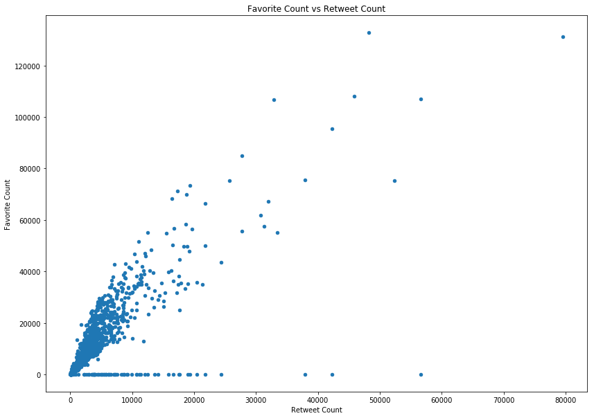

```python
sample_4.plot(x='retweet_count', y='favorite_count', kind='scatter', figsize=(14,10));
plt.title('Favorite Count vs Retweet Count');
plt.xlabel('Retweet Count');
plt.ylabel('Favorite Count');
```